# trial results

Allen Yeh

```r
library(tidyverse)
library(gmodels)
library(rstatix)
```

```r
library(ggplot2)
library(ez)

#increase print limit to 2500 values
options(max.print=3000)
```

### Import data

#### Read the csv file and claim the data type

```r
participant_id = c("1", "2", "3", "4", "5", "6", "7", "8", "9", "10", "11", "12", "13", "14", "15", "16", "17", "18", "19", "20", "21", "23", "24", "40")

key_code = c("A", "S", "D", "F", "J", "K", "L", "Semicolon")

level_code = c("full", "mediumHigh", "mediumLow", "medium", "light")

# Initialize an empty data frame
trial_log = NULL

for (x in participant_id) {
  filename <- paste("./../results/", x, ".csv", sep="")
  trial_user_log <- read_csv(filename, col_types = cols(
    id = col_factor(levels = participant_id),
    level = col_integer(),
    block = col_factor(levels = c("0", "1", "2", "3", "4", "5")),
    trial = col_integer(),
    levelCounts = col_factor(levels = c("2", "3", "4")),
    targetKey = col_factor(levels = key_code),
    targetLevel = col_factor(levels = level_code),
    pressedLevel = col_factor(levels = level_code),
    pressedRaw = col_integer(),
    isSuccessful = col_logical(),
    startTime = col_double(),
    endTime = col_double(),
    time = col_double(),
  )) %>% filter(block %in% c("1", "2", "3", "4", "5"))
  trial_log = bind_rows(trial_log,trial_user_log)
}
```

### functions

```r
percent <- function(num, digits = 2, ...) {
  percentage <-formatC(num * 100, format = "f", digits = digits, ...)

  # appending "%" symbol at the end of
  # calculate percentage value
  paste0(percentage, "%")
}

INT <- function(x){
    qnorm((rank(x) - 0.5)/length(x))
}
```

### Filter outlier with time

```r
trial_log_filtered <- trial_log %>%
  group_by(id, levelCounts) %>%
  mutate(IQR = IQR(time),
            O_upper = quantile(time, probs=c( .75), na.rm = FALSE)+1.5*IQR,
            O_lower = quantile(time, probs=c( .25), na.rm = FALSE)-1.5*IQR
  ) %>%
  filter(O_lower <= time & time <= O_upper)%>%
  ungroup()
```

Total 437 trials (5.1%) got removed.

### Total

#### block accuracy

```r
log_block_accuracy <- trial_log_filtered %>%
  group_by(id, levelCounts, block) %>%
  summarize(
    accuracy_ave = sum(isSuccessful) / n(),
    n_trials = n()
  ) %>%
  ungroup() %>%
  arrange(id, levelCounts, block)
log_accuracy_summary <- log_block_accuracy  %>%
  group_by(block, levelCounts) %>%
  summarize(
    meanAccuracy = accuracy_ave %>% mean(na.rm=TRUE),
    lowCIAccuracy = ci(accuracy_ave)[2] %>% pmax(0),
    highCIAccuracy = ci(accuracy_ave)[3] %>% pmin(1),
    sdAccuracy = ci(accuracy_ave)[4],
    stdAccuracy = sd(accuracy_ave)) %>%
  ungroup() %>%
  arrange(block, levelCounts)
log_accuracy_summary
```

```
## # A tibble: 15 × 7
##    block levelCounts meanAccuracy lowCIAccuracy highCIAccuracy sdAccuracy
##    <fct> <fct>              <dbl>         <dbl>          <dbl>      <dbl>
##  1 1     2                  0.866         0.815          0.917     0.0248
##  2 1     3                  0.731         0.681          0.781     0.0242
##  3 1     4                  0.598         0.547          0.650     0.0249
##  4 2     2                  0.928         0.897          0.959     0.0149
##  5 2     3                  0.742         0.699          0.786     0.0210
##  6 2     4                  0.588         0.541          0.635     0.0228
##  7 3     2                  0.902         0.866          0.937     0.0173
##  8 3     3                  0.734         0.676          0.792     0.0279
##  9 3     4                  0.644         0.601          0.686     0.0206
## 10 4     2                  0.928         0.893          0.962     0.0167
## 11 4     3                  0.773         0.737          0.808     0.0171
## 12 4     4                  0.613         0.565          0.660     0.0228
## 13 5     2                  0.936         0.907          0.965     0.0141
## 14 5     3                  0.755         0.714          0.797     0.0201
## 15 5     4                  0.619         0.576          0.661     0.0206
## # ℹ 1 more variable: stdAccuracy <dbl>
```

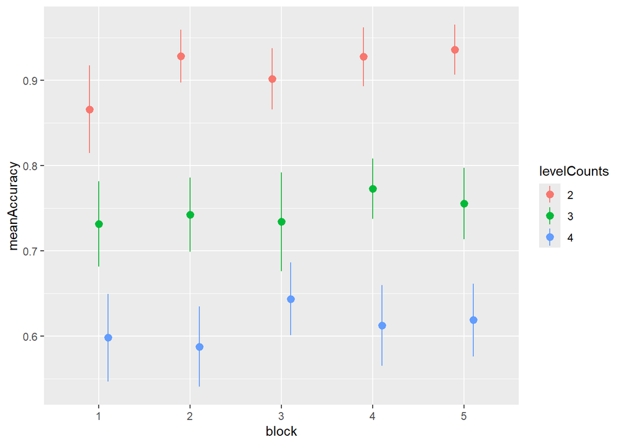

```r
pd <- position_dodge(width = 0.3)
log_accuracy_summary %>% ggplot(
  aes(
    x = block,
    y = meanAccuracy,
    ymin = lowCIAccuracy,
    ymax = highCIAccuracy,
    color = levelCounts
  )
) +
  geom_pointrange(position = pd)
```

```r
m = aov(accuracy_ave ~ block*levelCounts, data=log_block_accuracy) # make anova-type linear model
shapiro.test(residuals(m))
```

```
##
##  Shapiro-Wilk normality test
##
## data:  residuals(m)
## W = 0.98884, p-value = 0.007465
```

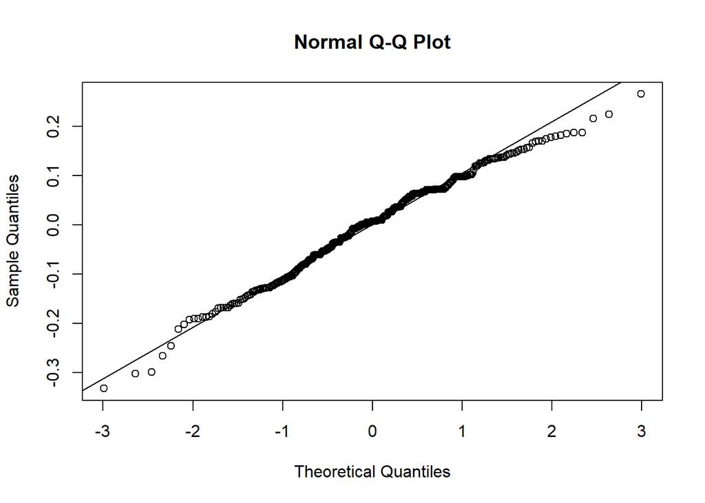

```r
qqnorm(residuals(m)); qqline(residuals(m)) # Q-Q plot
```

```r
library(ez) # for ezANOVA
log_block_accuracy$id = factor(log_block_accuracy$id)
m = ezANOVA(dv=accuracy_ave, within=c(block, levelCounts), wid=id, data=log_block_accuracy)
m$Mauchly # p<.05 indicates a sphericity violation
```

```
##              Effect         W         p p<.05
## 2             block 0.7491235 0.7221503
## 3       levelCounts 0.9771735 0.7756909
## 4 block:levelCounts 0.1149069 0.1631319
```

```r
m$ANOVA # use if no violation
```

```
##              Effect DFn DFd          F            p p<.05        ges
## 2             block   4  92   3.377571 1.261564e-02     * 0.01981354
## 3       levelCounts   2  46 124.950367 2.553119e-19     * 0.59658601
## 4 block:levelCounts   8 184   1.539318 1.462588e-01       0.02073490
```

```r
pairwise.t.test(log_block_accuracy$accuracy_ave, log_block_accuracy$block, paired=TRUE, p.adjust="holm")
```

```
##
##  Pairwise comparisons using paired t tests
##
## data:  log_block_accuracy$accuracy_ave and log_block_accuracy$block
##
##   1     2     3     4
## 2 0.911 -     -     -
## 3 0.301 1.000 -     -
## 4 0.022 0.911 1.000 -
## 5 0.100 0.911 1.000 1.000
##
## P value adjustment method: holm
```

Effect on block, pairwise only showed the difference between block 1 and 4. Remove block 1 for following test.

#### levelCount accuracy

```r
trial_log_filtered <- trial_log_filtered %>%
  filter(block != c("1"))

log_accuracy <- trial_log_filtered %>%
  group_by(id, levelCounts) %>%
  summarize(
    accuracy_ave = sum(isSuccessful) / n(),
    n_trials = n()
  ) %>%
  ungroup() %>%
  arrange(id, levelCounts)
```

[output not shown]

```r
log_accuracy_summary <- log_accuracy  %>%
  group_by(levelCounts) %>%
  summarize(
    meanAccuracy = accuracy_ave %>% mean(na.rm=TRUE),
    lowCIAccuracy = ci(accuracy_ave)[2] %>% pmax(0),
    highCIAccuracy = ci(accuracy_ave)[3] %>% pmin(1),
    sdAccuracy = ci(accuracy_ave)[4],
    stdAccuracy = sd(accuracy_ave)) %>%
  ungroup() %>%
  arrange(levelCounts)

log_accuracy_summary
```

```
## # A tibble: 3 × 6
##   levelCounts meanAccuracy lowCIAccuracy highCIAccuracy sdAccuracy stdAccuracy
##   <fct>              <dbl>         <dbl>          <dbl>      <dbl>       <dbl>
## 1 2                  0.924         0.900          0.948     0.0116      0.0571
## 2 3                  0.751         0.720          0.782     0.0151      0.0742
## 3 4                  0.616         0.580          0.652     0.0173      0.0846
```

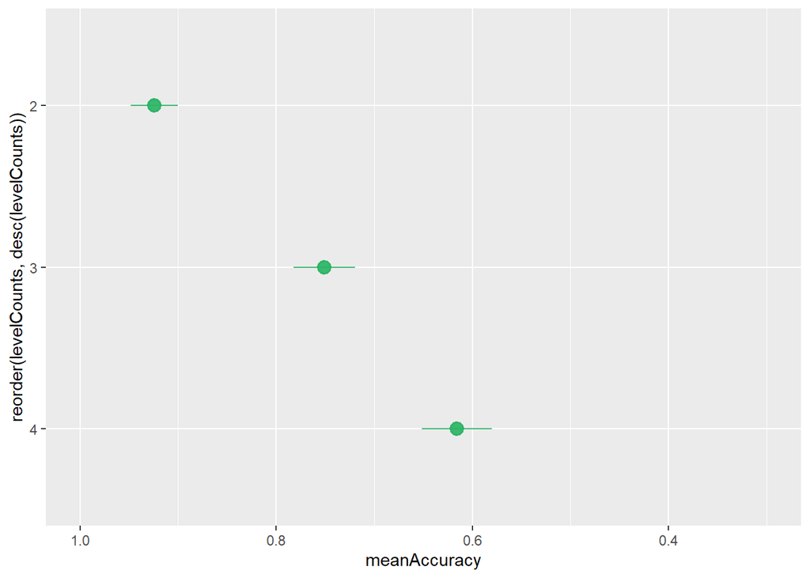

```r
# pd <- position_dodge(width = 0.3)
# log_accuracy_summary %>% ggplot(
#   aes(
#     x = levelCounts,
#     y = meanAccuracy,
#     ymin = lowCIAccuracy,
#     ymax = highCIAccuracy
#   )
# ) +
#   geom_pointrange(position = pd)

# line + dot
accuracy_graph <- ggplot(log_accuracy_summary) +
  geom_pointrange( aes(x=reorder(levelCounts, desc(levelCounts)), y=meanAccuracy, ymin=lowCIAccuracy, ymax=highCIAccuracy), colour="#28b463", alpha=0.9, size=0.8) +
  scale_y_reverse(lim=c(1.0,0.3)) +
  coord_flip()

accuracy_graph
```

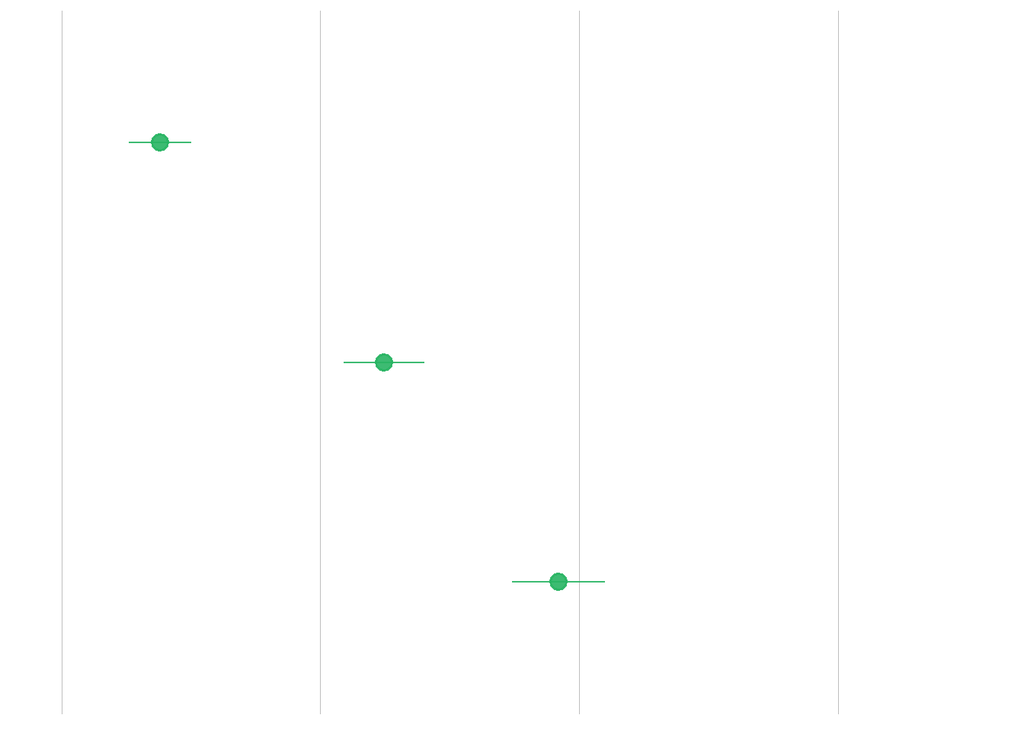

```r
accuracy_graph + theme( # remove the vertical grid lines
          panel.background = element_blank(),
          panel.grid.major.y = element_blank() ,
          # explicitly set the horizontal lines (or they will disappear too)
          panel.grid.major.x = element_line( size=.1, color="gray" ),
          axis.title.x = element_blank(),
          axis.text.x=element_blank(),
          axis.ticks.x = element_blank(),
          axis.title.y = element_blank(),
          axis.text.y=element_blank(),
          axis.ticks.y = element_blank()
    )
```

```r
ggsave("accuracy_levels.pdf", width = 4, height = 3)
```

##### levelCount accuracy analysis

```r
m = aov(accuracy_ave ~ levelCounts, data=log_accuracy) # make anova-type linear model
shapiro.test(residuals(m))
```

```
##
##  Shapiro-Wilk normality test
##
## data:  residuals(m)
## W = 0.98707, p-value = 0.673
```

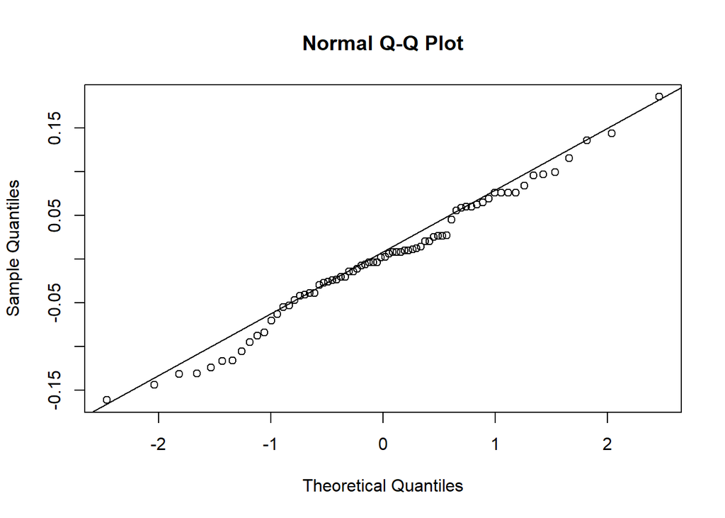

```r
qqnorm(residuals(m)); qqline(residuals(m)) # Q-Q plot
```

```r
library(ez) # for ezANOVA
log_accuracy$id = factor(log_accuracy$id)
m = ezANOVA(dv=accuracy_ave, within=c(levelCounts), wid=id, data=log_accuracy)
m$Mauchly # p<.05 indicates a sphericity violation
```

```
##        Effect         W         p p<.05
## 2 levelCounts 0.9208611 0.4037712
```

```r
m$ANOVA # use if no violation
```

```
##        Effect DFn DFd        F            p p<.05       ges
## 2 levelCounts   2  46 151.2139 5.954338e-21     * 0.7577248
```

```r
pairwise.t.test(log_accuracy$accuracy_ave, log_accuracy$levelCounts, paired=TRUE, p.adjust="holm")
```

```
##
##  Pairwise comparisons using paired t tests
##
## data:  log_accuracy$accuracy_ave and log_accuracy$levelCounts
##
##   2       3
## 3 2.6e-09 -
## 4 1.5e-15 5.9e-07
##
## P value adjustment method: holm
```

2 levels is better than 3 and 4 levels. 3 levels is better than 4 levels.

#### levelCount time

```r
log_time <- trial_log_filtered %>%
  group_by(id, levelCounts) %>%
  summarize(
    time_ave = sum(time) / n(),
    n_trials = n()
  ) %>%
  ungroup() %>%
  arrange(id, levelCounts)
```

[output not shown]

```r
log_time_summary <- log_time  %>%
  group_by(levelCounts) %>%
  summarize(
    meanTime = time_ave %>% mean(na.rm=TRUE),
    lowCITime = ci(time_ave)[2] %>% pmax(0),
    highCITime = ci(time_ave)[3],
    sdTime = ci(time_ave)[4],
    stdTime = sd(time_ave)) %>%
  ungroup() %>%
  arrange(levelCounts)

log_time_summary
```

```
## # A tibble: 3 × 6
##   levelCounts meanTime lowCITime highCITime sdTime stdTime
##   <fct>          <dbl>     <dbl>      <dbl>  <dbl>   <dbl>
## 1 2              1137.     1051.      1222.   41.4    203.
## 2 3              1330.     1224.      1436.   51.2    251.
## 3 4              1547.     1423.      1671.   59.8    293.
```

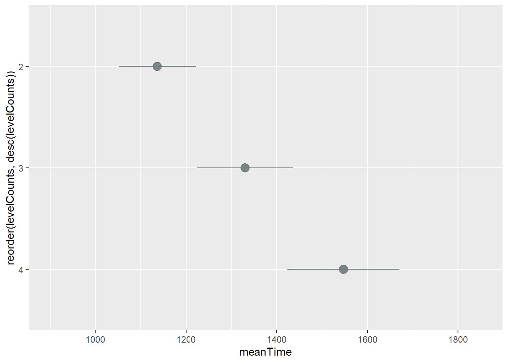

```r
# pd <- position_dodge(width = 0.3)
# log_time_summary %>% ggplot(
#   aes(
#     x = levelCounts,
#     y = meanTime,
#     ymin = lowCITime,
#     ymax = highCITime
#   )
# ) +
#   geom_pointrange(position = pd)

# line + dot
time_graph <- ggplot(log_time_summary) +
  geom_pointrange( aes(x=reorder(levelCounts, desc(levelCounts)), y=meanTime, ymin=lowCITime, ymax=highCITime), colour="#707b7c", alpha=0.9, size=0.8) +
  scale_y_continuous(lim=c(900,1850)) +
  coord_flip()

time_graph
```

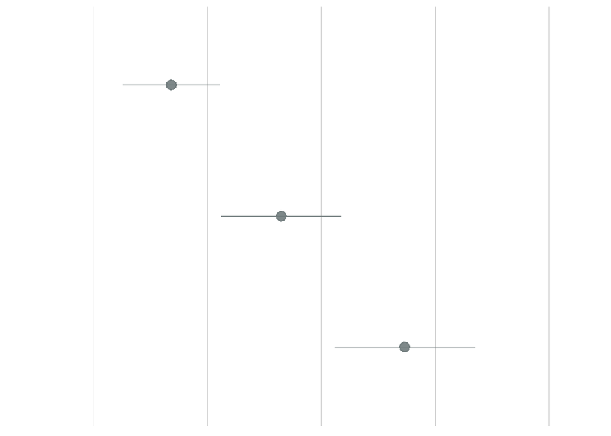

```r
time_graph + theme( # remove the vertical grid lines
          panel.background = element_blank(),
          panel.grid.major.y = element_blank() ,
          # explicitly set the horizontal lines (or they will disappear too)
          panel.grid.major.x = element_line( size=.1, color="gray" ),
          axis.title.x = element_blank(),
          axis.text.x=element_blank(),
          axis.ticks.x = element_blank(),
          axis.title.y = element_blank(),
          axis.text.y=element_blank(),
          axis.ticks.y = element_blank()
    )
```

```r
ggsave("time_levels.pdf", width = 4, height = 3)
```

##### levelCount time analysis

```r
m = aov(time_ave ~ levelCounts, data=log_time) # make anova-type linear model
shapiro.test(residuals(m))
```

```
##
##  Shapiro-Wilk normality test
##
## data:  residuals(m)
## W = 0.96215, p-value = 0.02926
```

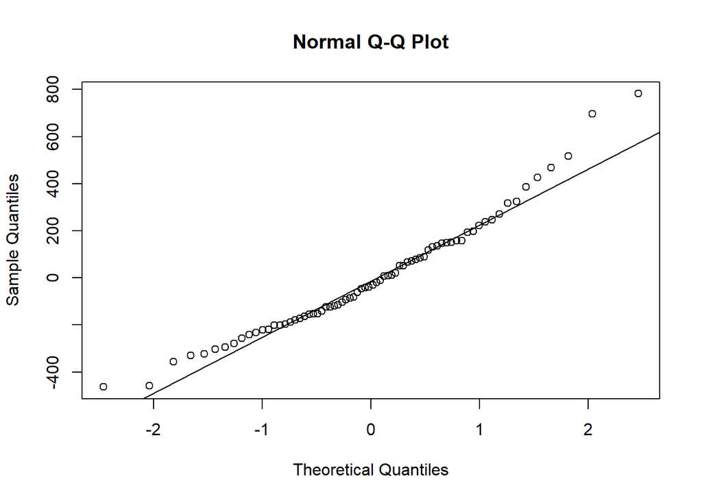

```r
qqnorm(residuals(m)); qqline(residuals(m)) # Q-Q plot
```

```r
library(rcompanion)
log_time$time_ave_trans = transformTukey(log_time$time_ave)
```

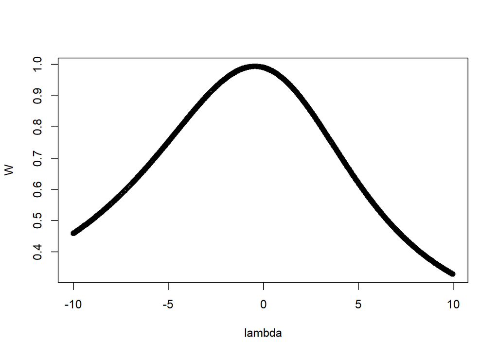

```
##
##     lambda      W Shapiro.p.value
## 381   -0.5 0.9941           0.984
##
## if (lambda >  0){TRANS = x ^ lambda}
## if (lambda == 0){TRANS = log(x)}
## if (lambda <  0){TRANS = -1 * x ^ lambda}
```

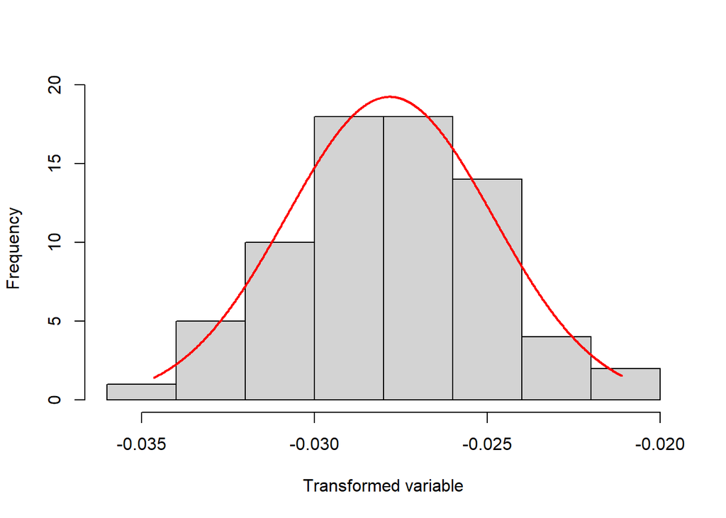

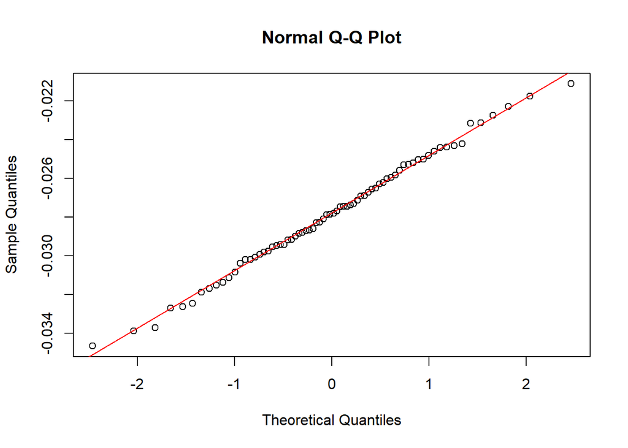

```r
m = aov(time_ave_trans ~ levelCounts, data=log_time) # make anova-type linear model
shapiro.test(residuals(m))
```

```
##
##  Shapiro-Wilk normality test
##
## data:  residuals(m)
## W = 0.9931, p-value = 0.9653
```

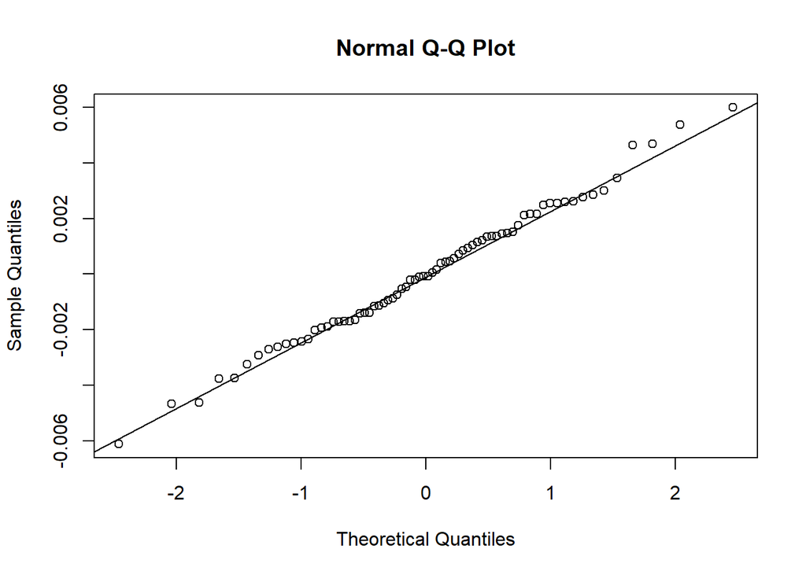

```r
qqnorm(residuals(m)); qqline(residuals(m)) # Q-Q plot
```

```r
library(ez) # for ezANOVA
log_time$id = factor(log_time$id)
m = ezANOVA(dv=time_ave_trans, within=c(levelCounts), wid=id, data=log_time)
m$Mauchly # p<.05 indicates a sphericity violation
```

```
##        Effect         W         p p<.05
## 2 levelCounts 0.9266127 0.4323953
```

```r
m$ANOVA # use if no violation
```

```
##        Effect DFn DFd        F            p p<.05       ges
## 2 levelCounts   2  46 114.3046 1.422284e-18     * 0.3400717
```

```r
pairwise.t.test(log_time$time_ave_trans, log_time$levelCounts, paired=TRUE, p.adjust="holm")
```

```
##
##  Pairwise comparisons using paired t tests
##
## data:  log_time$time_ave_trans and log_time$levelCounts
##
##   2       3
## 3 7.2e-08 -
## 4 4.1e-12 4.5e-08
##
## P value adjustment method: holm
```

Using tucky for normalization. 2 levels is faster than 3 and 4 levels. 3 levels is faster than 4 levels.

### 2 level

#### accuracy

```r
log_twolevel_accuracy <- trial_log_filtered %>%
  filter(levelCounts == c("2")) %>%
  group_by(id, targetLevel, targetKey) %>%
  summarize(
    accuracy_ave = sum(isSuccessful) / n(),
    n_trials = n()
  ) %>%
  ungroup() %>%
  arrange(id, targetLevel, targetKey)
log_twolevel_accuracy_summary <- log_twolevel_accuracy  %>%
  group_by(targetLevel, targetKey) %>%
  summarize(
    meanAccuracy = accuracy_ave %>% mean(na.rm=TRUE),
    lowCIAccuracy = ci(accuracy_ave)[2] %>% pmax(0),
    highCIAccuracy = ci(accuracy_ave)[3] %>% pmin(1),
    sdAccuracy = ci(accuracy_ave)[4],
    stdAccuracy = sd(accuracy_ave)) %>%
  ungroup() %>%
  arrange(targetLevel, targetKey)
log_twolevel_accuracy_summary
```

```
## # A tibble: 16 × 7
##    targetLevel targetKey meanAccuracy lowCIAccuracy highCIAccuracy sdAccuracy
##    <fct>       <fct>            <dbl>         <dbl>          <dbl>      <dbl>
##  1 full        A                0.990         0.968          1         0.0104
##  2 full        S                0.927         0.869          0.985     0.0281
##  3 full        D                0.958         0.918          0.999     0.0194
##  4 full        F                0.979         0.936          1         0.0208
##  5 full        J                0.958         0.918          0.999     0.0194
##  6 full        K                0.948         0.894          1         0.0260
##  7 full        L                0.917         0.840          0.994     0.0372
##  8 full        Semicolon        0.938         0.881          0.994     0.0271
##  9 light       A                0.875         0.799          0.951     0.0369
## 10 light       S                0.865         0.802          0.927     0.0300
## 11 light       D                0.899         0.821          0.978     0.0379
## 12 light       F                0.896         0.798          0.994     0.0474
## 13 light       J                0.917         0.849          0.984     0.0325
## 14 light       K                0.958         0.907          1         0.0246
## 15 light       L                0.868         0.769          0.968     0.0481
## 16 light       Semicolon        0.924         0.849          0.998     0.0361
## # ℹ 1 more variable: stdAccuracy <dbl>
```

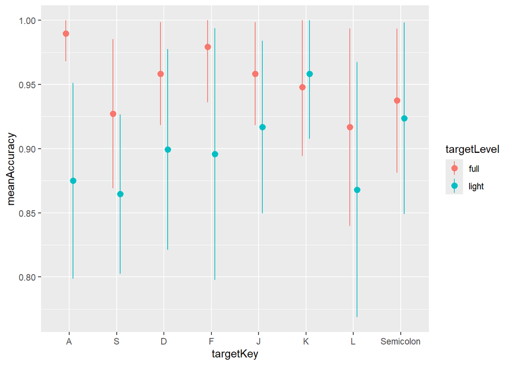

```r
pd <- position_dodge(width = 0.3)
log_twolevel_accuracy_summary %>% ggplot(
  aes(
    x = targetKey,
    y = meanAccuracy,
    ymin = lowCIAccuracy,
    ymax = highCIAccuracy,
    color = targetLevel
  )
) +
  geom_pointrange(position = pd)
```

```r
log_twolevel_accuracy_summary_level <- log_twolevel_accuracy  %>%
  group_by(targetLevel) %>%
  summarize(
    meanAccuracy = accuracy_ave %>% mean(na.rm=TRUE),
    lowCIAccuracy = ci(accuracy_ave)[2] %>% pmax(0),
    highCIAccuracy = ci(accuracy_ave)[3] %>% pmin(1),
    sdAccuracy = ci(accuracy_ave)[4],
    stdAccuracy = sd(accuracy_ave)) %>%
  ungroup() %>%
  arrange(targetLevel)

log_twolevel_accuracy_summary_level
```

```
## # A tibble: 2 × 6
##   targetLevel meanAccuracy lowCIAccuracy highCIAccuracy sdAccuracy stdAccuracy
##   <fct>              <dbl>         <dbl>          <dbl>      <dbl>       <dbl>
## 1 full               0.952         0.935          0.969    0.00873       0.121
## 2 light              0.900         0.874          0.926    0.0132        0.183
```

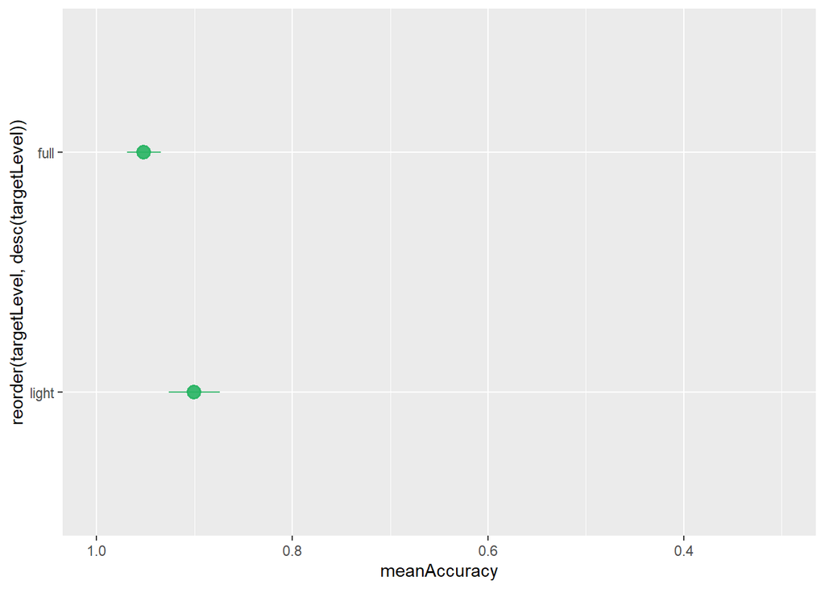

```r
# line + dot (levels)
twolevel_accuracy_level <- ggplot(log_twolevel_accuracy_summary_level) +
  geom_pointrange( aes(x=reorder(targetLevel, desc(targetLevel)), y=meanAccuracy, ymin=lowCIAccuracy, ymax=highCIAccuracy), colour="#28b463", alpha=0.9, size=0.8) +
  scale_y_reverse(lim=c(1.0,0.3)) +
  coord_flip()

twolevel_accuracy_level
```

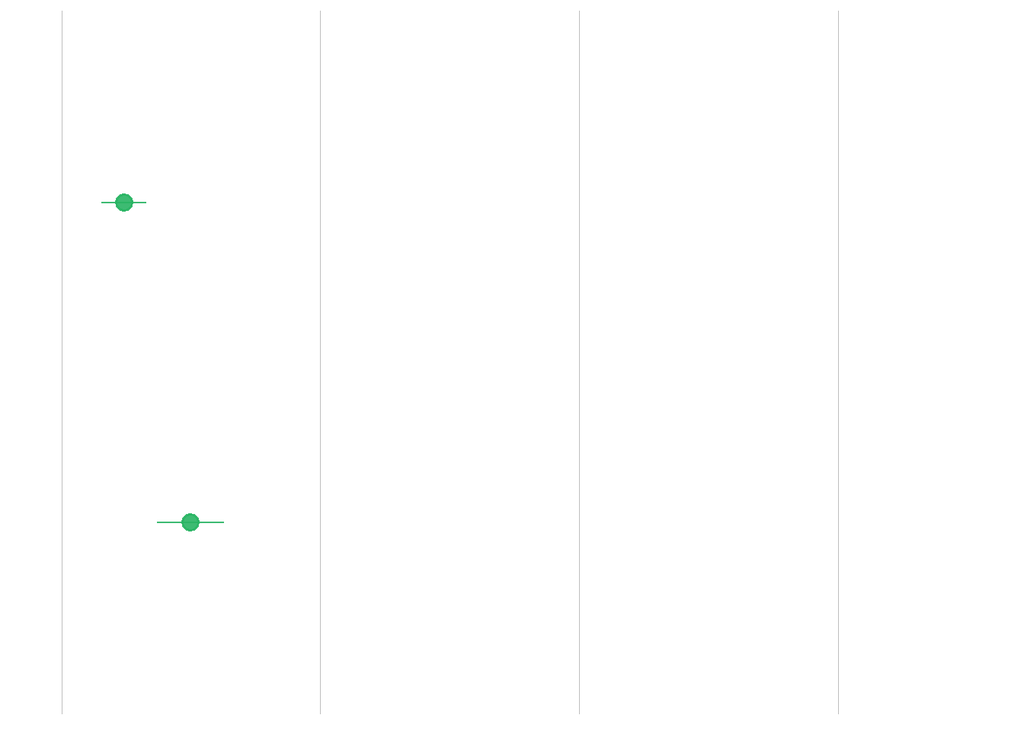

```r
twolevel_accuracy_level + theme( # remove the vertical grid lines
          panel.background = element_blank(),
          panel.grid.major.y = element_blank() ,
          # explicitly set the horizontal lines (or they will disappear too)
          panel.grid.major.x = element_line( size=.1, color="gray" ),
          axis.title.x = element_blank(),
          axis.text.x=element_blank(),
          axis.ticks.x = element_blank(),
          axis.title.y = element_blank(),
          axis.text.y=element_blank(),
          axis.ticks.y = element_blank()
    )
```

```r
ggsave("2level_accuracy_level.pdf", width = 4, height = 2)

log_twolevel_accuracy_summary_key <- log_twolevel_accuracy  %>%
  group_by(targetKey) %>%
  summarize(
    meanAccuracy = accuracy_ave %>% mean(na.rm=TRUE),
    lowCIAccuracy = ci(accuracy_ave)[2] %>% pmax(0),
    highCIAccuracy = ci(accuracy_ave)[3] %>% pmin(1),
    sdAccuracy = ci(accuracy_ave)[4],
    stdAccuracy = sd(accuracy_ave)) %>%
  ungroup() %>%
  arrange(targetKey)

log_twolevel_accuracy_summary_key
```

```
## # A tibble: 8 × 6
##   targetKey meanAccuracy lowCIAccuracy highCIAccuracy sdAccuracy stdAccuracy
##   <fct>            <dbl>         <dbl>          <dbl>      <dbl>       <dbl>
## 1 A                0.932         0.891          0.974     0.0207       0.143
## 2 S                0.896         0.854          0.938     0.0208       0.144
## 3 D                0.929         0.886          0.972     0.0215       0.149
## 4 F                0.938         0.885          0.990     0.0263       0.182
## 5 J                0.938         0.899          0.976     0.0190       0.131
## 6 K                0.953         0.918          0.989     0.0177       0.123
## 7 L                0.892         0.831          0.953     0.0303       0.210
## 8 Semicolon        0.931         0.886          0.976     0.0224       0.155
```

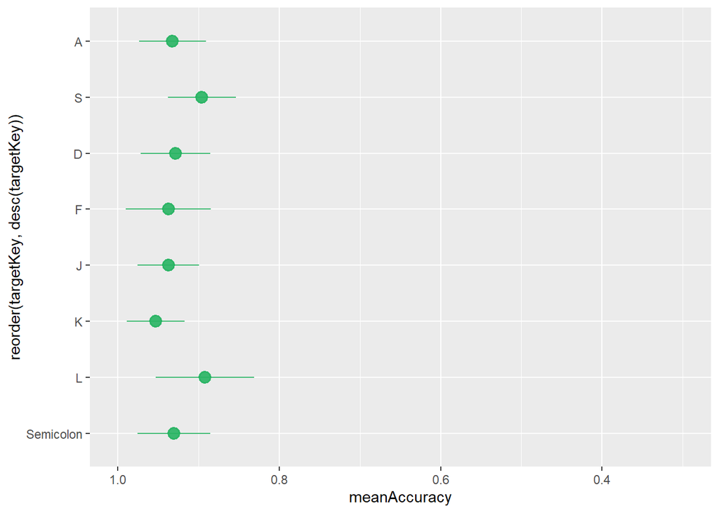

```r
# line + dot (key)
twolevel_accuracy_key <- ggplot(log_twolevel_accuracy_summary_key) +
  geom_pointrange( aes(x=reorder(targetKey, desc(targetKey)), y=meanAccuracy, ymin=lowCIAccuracy, ymax=highCIAccuracy), colour="#28b463", alpha=0.9, size=0.8) +
  scale_y_reverse(lim=c(1.0,0.3)) +
  coord_flip()

twolevel_accuracy_key
```

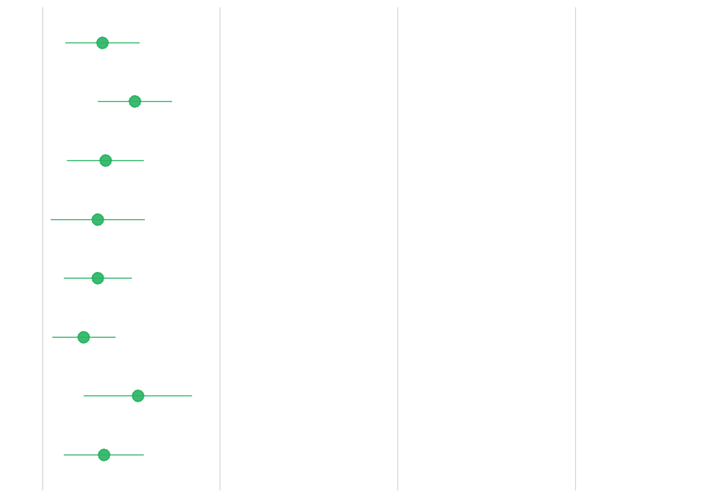

```r
twolevel_accuracy_key + theme( # remove the vertical grid lines
          panel.background = element_blank(),
          panel.grid.major.y = element_blank() ,
          # explicitly set the horizontal lines (or they will disappear too)
          panel.grid.major.x = element_line( size=.1, color="gray" ),
          axis.title.x = element_blank(),
          axis.text.x=element_blank(),
          axis.ticks.x = element_blank(),
          axis.title.y = element_blank(),
          axis.text.y=element_blank(),
          axis.ticks.y = element_blank()
    )
```

```r
ggsave("2level_accuracy_key.pdf", width = 4, height = 8)
```

##### accuracy analysis

```r
m = aov(accuracy_ave ~ targetLevel*targetKey, data=log_twolevel_accuracy) # make anova-type linear model
shapiro.test(residuals(m))
```

```
##
##  Shapiro-Wilk normality test
##
## data:  residuals(m)
## W = 0.72085, p-value < 2.2e-16
```

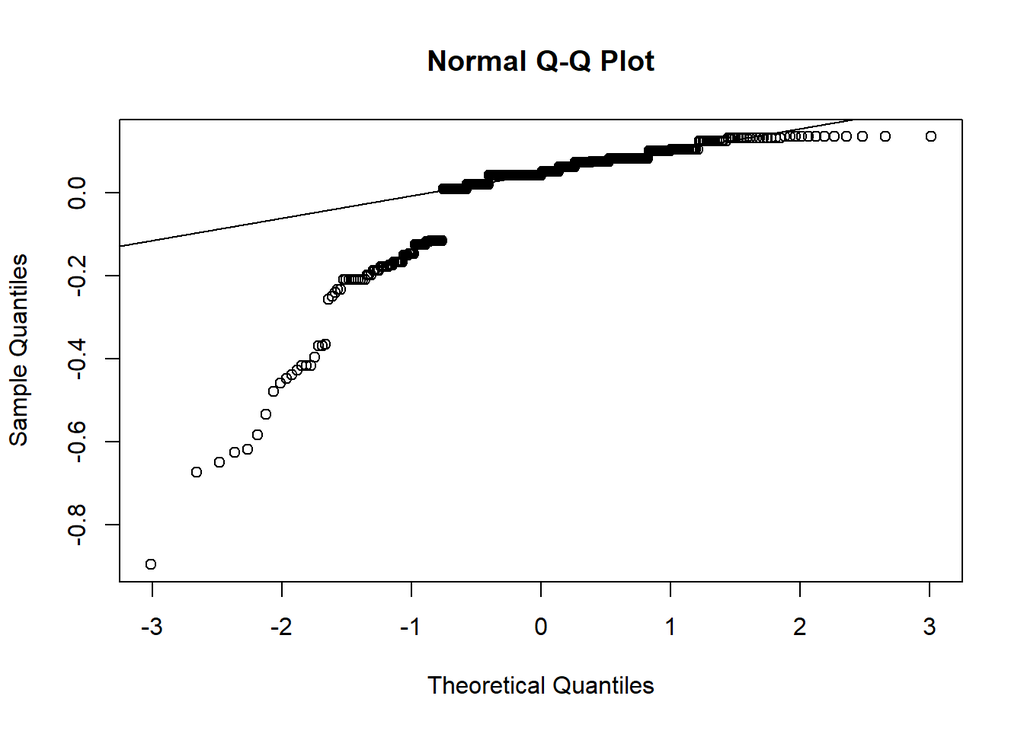

```r
qqnorm(residuals(m)); qqline(residuals(m)) # Q-Q plot
```

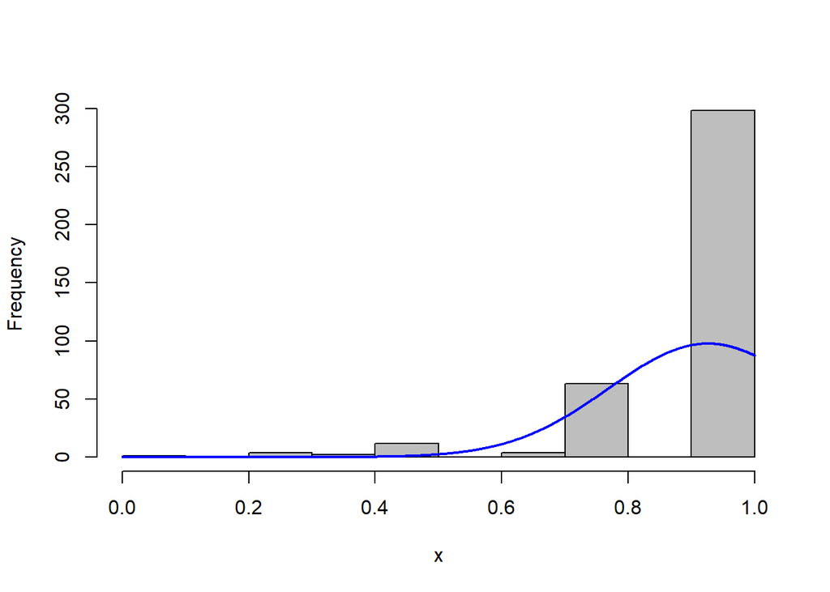

```r
plotNormalHistogram(log_twolevel_accuracy$accuracy_ave)
```

```r
#
# library(ez) # for ezANOVA
# log_twolevel_accuracy$id = factor(log_twolevel_accuracy$id)
# m = ezANOVA(dv=accuracy_ave, within=c(targetLevel,targetKey), wid=id, data=log_twolevel_accuracy)
# m$Mauchly # p<.05 indicates a sphericity violation
# m$ANOVA # use if no violation


library(lme4)
library(lmerTest)
library(car)
log_twolevel_accuracy$id = factor(log_twolevel_accuracy$id)
contrasts(log_twolevel_accuracy$targetLevel) <-"contr.sum"
contrasts(log_twolevel_accuracy$targetKey) <-"contr.sum"
m = glmer(accuracy_ave ~ targetLevel*targetKey + (1|id), data=log_twolevel_accuracy, family=poisson)
# use family=quasipoissonif overdispersion
Anova(m, type=3)
```

```
## Analysis of Deviance Table (Type III Wald chisquare tests)
##
## Response: accuracy_ave
##                        Chisq Df Pr(>Chisq)
## (Intercept)           0.0558  1     0.8133
## targetLevel           0.2787  1     0.5975
## targetKey             0.1091  7     1.0000
## targetLevel:targetKey 0.1366  7     1.0000
```

No effect.

#### time

```r
log_twoLevel_time <- trial_log_filtered%>%
  filter(levelCounts == c("2")) %>%
  group_by(id, targetLevel, targetKey) %>%
  summarize(
    time_ave = sum(time) / n(),
    n_trials = n()
  ) %>%
  ungroup() %>%
  arrange(id, targetLevel, targetKey)
log_twoLevel_time_summary <- log_twoLevel_time  %>%
  group_by(targetLevel, targetKey) %>%
  summarize(
    meanTime = time_ave %>% mean(na.rm=TRUE),
    lowCITime = ci(time_ave)[2] %>% pmax(0),
    highCITime = ci(time_ave)[3],
    sdTime = ci(time_ave)[4],
    stdTime = sd(time_ave)) %>%
  ungroup() %>%
  arrange(targetLevel, targetKey)
log_twoLevel_time_summary
```

```
## # A tibble: 16 × 7
##    targetLevel targetKey meanTime lowCITime highCITime sdTime stdTime
##    <fct>       <fct>        <dbl>     <dbl>      <dbl>  <dbl>   <dbl>
##  1 full        A            1007.      906.      1107.   48.7    238.
##  2 full        S            1099.     1008.      1191.   44.2    216.
##  3 full        D            1193.     1080.      1307.   54.9    269.
##  4 full        F            1142.     1033.      1250.   52.4    257.
##  5 full        J            1170.     1063.      1277.   51.7    253.
##  6 full        K            1286.     1172.      1400.   55.2    270.
##  7 full        L            1221.     1133.      1309.   42.6    209.
##  8 full        Semicolon    1125.     1021.      1228.   50.2    246.
##  9 light       A             996.      916.      1076.   38.8    190.
## 10 light       S            1073.      967.      1179.   51.4    252.
## 11 light       D            1133.     1021.      1245.   54.0    265.
## 12 light       F            1128.     1008.      1248.   57.9    284.
## 13 light       J            1176.     1066.      1286.   53.3    261.
## 14 light       K            1238.     1143.      1333.   45.9    225.
## 15 light       L            1197.     1071.      1323.   60.9    298.
## 16 light       Semicolon    1089.      979.      1199.   53.3    261.
```

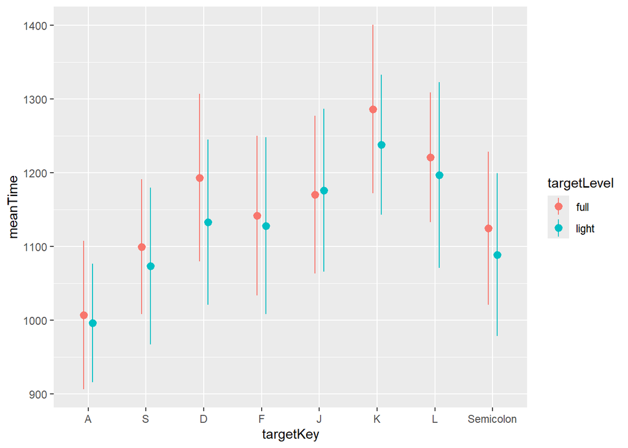

```r
pd <- position_dodge(width = 0.3)
log_twoLevel_time_summary %>% ggplot(
  aes(
    x = targetKey,
    y = meanTime,
    ymin = lowCITime,
    ymax = highCITime,
    color = targetLevel
  )
) +
  geom_pointrange(position = pd)
```

```r
log_twoLevel_time_summary_level <- log_twoLevel_time  %>%
  group_by(targetLevel) %>%
  summarize(
    meanTime = time_ave %>% mean(na.rm=TRUE),
    lowCITime = ci(time_ave)[2] %>% pmax(0),
    highCITime = ci(time_ave)[3],
    sdTime = ci(time_ave)[4],
    stdTime = sd(time_ave)) %>%
  ungroup() %>%
  arrange(targetLevel)

log_twoLevel_time_summary_level
```

```
## # A tibble: 2 × 6
##   targetLevel meanTime lowCITime highCITime sdTime stdTime
##   <fct>          <dbl>     <dbl>      <dbl>  <dbl>   <dbl>
## 1 full           1155.     1119.      1191.   18.3    254.
## 2 light          1129.     1091.      1166.   18.9    262.
```

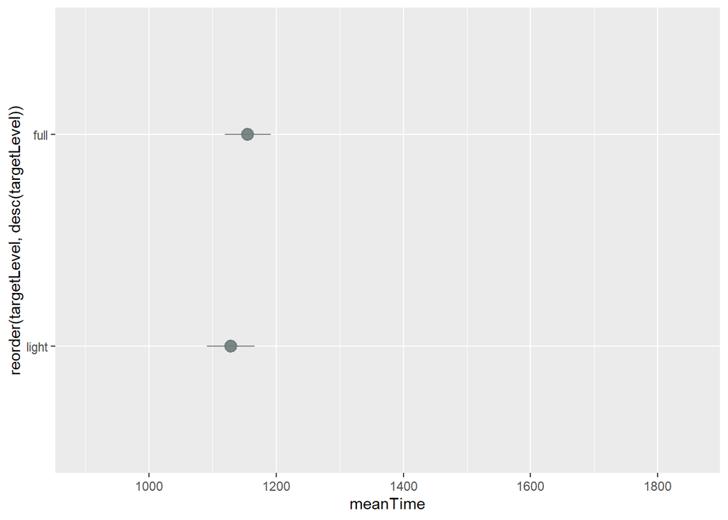

```r
# line + dot (levels)
twolevel_time_level <- ggplot(log_twoLevel_time_summary_level) +
  geom_pointrange( aes(x=reorder(targetLevel, desc(targetLevel)), y=meanTime, ymin=lowCITime, ymax=highCITime), colour="#707b7c", alpha=0.9, size=0.8) +
  scale_y_continuous(lim=c(900,1850)) +
  coord_flip()

twolevel_time_level
```

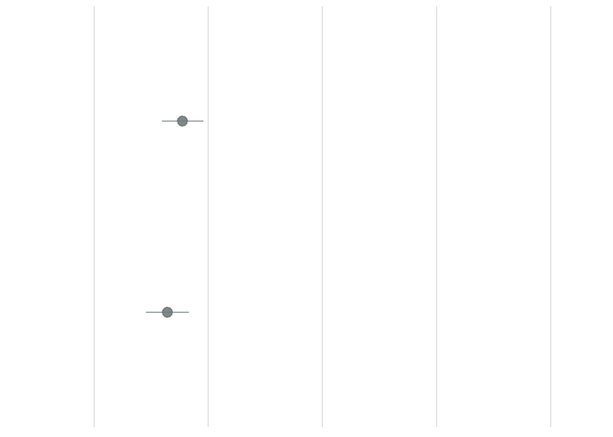

```r
twolevel_time_level + theme( # remove the vertical grid lines
          panel.background = element_blank(),
          panel.grid.major.y = element_blank() ,
          # explicitly set the horizontal lines (or they will disappear too)
          panel.grid.major.x = element_line( size=.1, color="gray" ),
          axis.title.x = element_blank(),
          axis.text.x=element_blank(),
          axis.ticks.x = element_blank(),
          axis.title.y = element_blank(),
          axis.text.y=element_blank(),
          axis.ticks.y = element_blank()
    )
```

```r
ggsave("2level_time_level.pdf", width = 4, height = 2)

log_twoLevel_time_summary_key <- log_twoLevel_time  %>%
  group_by(targetKey) %>%
  summarize(
    meanTime = time_ave %>% mean(na.rm=TRUE),
    lowCITime = ci(time_ave)[2] %>% pmax(0),
    highCITime = ci(time_ave)[3],
    sdTime = ci(time_ave)[4],
    stdTime = sd(time_ave)) %>%
  ungroup() %>%
  arrange(targetKey)

log_twoLevel_time_summary_key
```

```
## # A tibble: 8 × 6
##   targetKey meanTime lowCITime highCITime sdTime stdTime
##   <fct>        <dbl>     <dbl>      <dbl>  <dbl>   <dbl>
## 1 A            1001.      939.      1063.   30.8    213.
## 2 S            1086.     1019.      1154.   33.6    233.
## 3 D            1163.     1086.      1240.   38.4    266.
## 4 F            1135.     1057.      1213.   38.6    268.
## 5 J            1173.     1099.      1247.   36.7    255.
## 6 K            1262.     1190.      1334.   35.7    247.
## 7 L            1209.     1135.      1283.   36.8    255.
## 8 Semicolon    1107.     1034.      1180.   36.3    251.
```

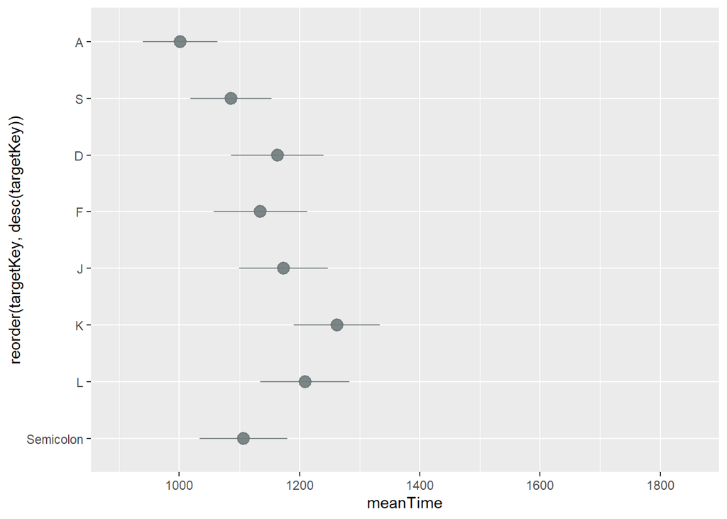

```r
# line + dot (key)
twolevel_time_key <- ggplot(log_twoLevel_time_summary_key) +
  geom_pointrange( aes(x=reorder(targetKey, desc(targetKey)), y=meanTime, ymin=lowCITime, ymax=highCITime), colour="#707b7c", alpha=0.9, size=0.8) +
  scale_y_continuous(lim=c(900,1850)) +
  coord_flip()

twolevel_time_key
```

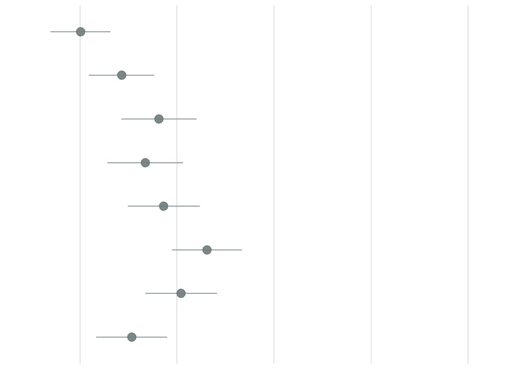

```r
twolevel_time_key + theme( # remove the vertical grid lines
          panel.background = element_blank(),
          panel.grid.major.y = element_blank() ,
          # explicitly set the horizontal lines (or they will disappear too)
          panel.grid.major.x = element_line( size=.1, color="gray" ),
          axis.title.x = element_blank(),
          axis.text.x=element_blank(),
          axis.ticks.x = element_blank(),
          axis.title.y = element_blank(),
          axis.text.y=element_blank(),
          axis.ticks.y = element_blank()
    )
```

```r
ggsave("2level_time_key.pdf", width = 4, height = 8)
```

##### time analysis

```r
m = aov(time_ave ~ targetLevel*targetKey, data=log_twoLevel_time) # make anova-type linear model
shapiro.test(residuals(m))
```

```
##
##  Shapiro-Wilk normality test
##
## data:  residuals(m)
## W = 0.9422, p-value = 4.44e-11
```

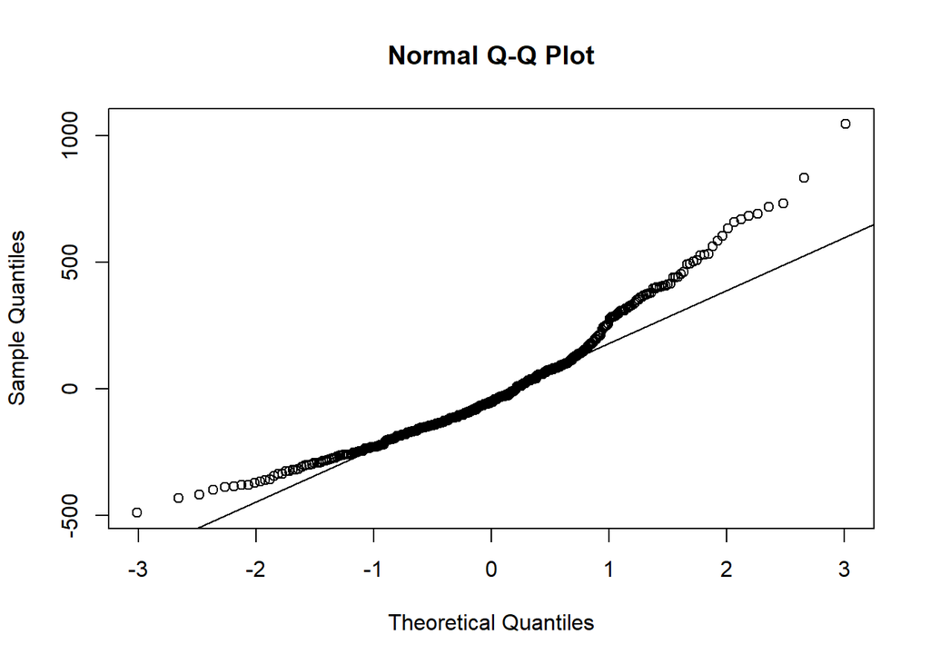

```r
qqnorm(residuals(m)); qqline(residuals(m)) # Q-Q plot
```

```r
library(rcompanion)
log_twoLevel_time$time_ave_trans = transformTukey(log_twoLevel_time$time_ave)
```

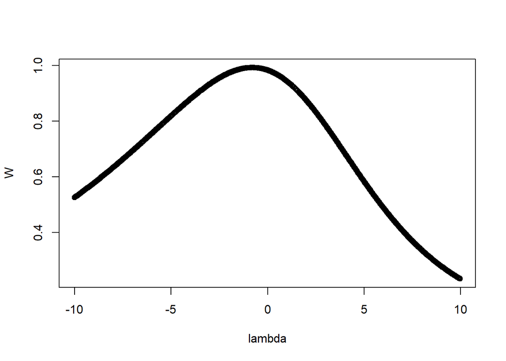

```
##
##     lambda      W Shapiro.p.value
## 369   -0.8 0.9931         0.07315
##
## if (lambda >  0){TRANS = x ^ lambda}
## if (lambda == 0){TRANS = log(x)}
## if (lambda <  0){TRANS = -1 * x ^ lambda}
```

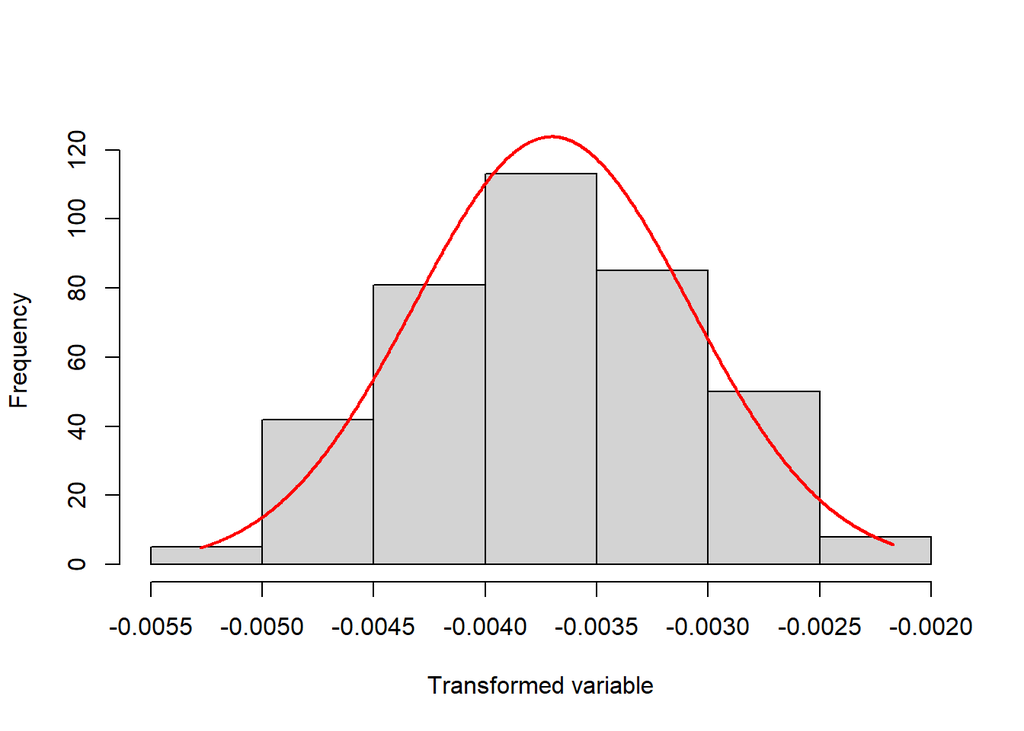

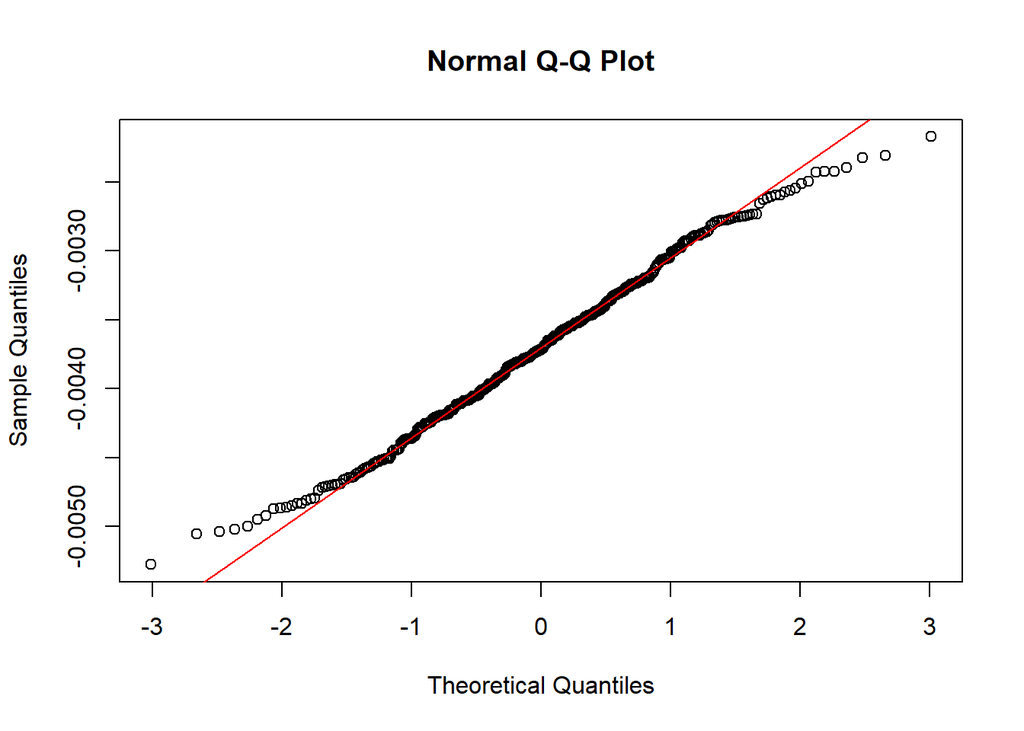

```r
m = aov(time_ave_trans ~ targetLevel*targetKey, data=log_twoLevel_time) # make anova-type linear model
shapiro.test(residuals(m))
```

```
##
##  Shapiro-Wilk normality test
##
## data:  residuals(m)
## W = 0.99465, p-value = 0.2027
```

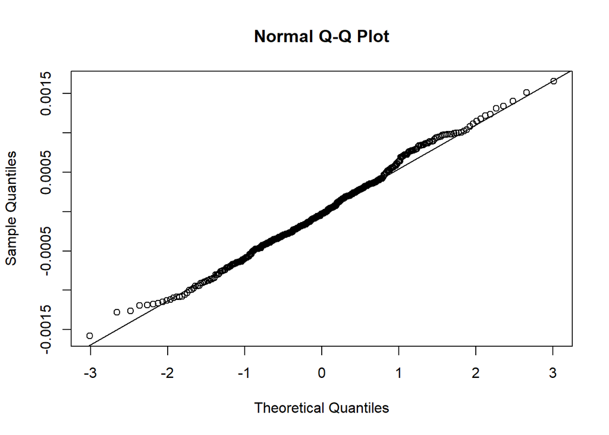

```r
qqnorm(residuals(m)); qqline(residuals(m)) # Q-Q plot
```

```r
library(ez) # for ezANOVA
log_twoLevel_time$id = factor(log_twoLevel_time$id)
m = ezANOVA(dv=time_ave_trans, within=c(targetLevel,targetKey), wid=id, data=log_twoLevel_time, return_aov = TRUE)
m$Mauchly # p<.05 indicates a sphericity violation
```

```
##                  Effect         W         p p<.05
## 3             targetKey 0.2227409 0.2923430
## 4 targetLevel:targetKey 0.3713933 0.8249573
```

```r
m$ANOVA # use if no violation
```

```
##                  Effect DFn DFd          F            p p<.05         ges
## 2           targetLevel   1  23  2.5895157 1.212145e-01       0.005116521
## 3             targetKey   7 161 13.9064611 4.965811e-14     * 0.102062106
## 4 targetLevel:targetKey   7 161  0.3570104 9.257236e-01       0.001930686
```

```r
pairwise.t.test(log_twoLevel_time$time_ave_trans, log_twoLevel_time$targetKey, paired=TRUE, p.adjust="holm")
```

```
##
##  Pairwise comparisons using paired t tests
##
## data:  log_twoLevel_time$time_ave_trans and log_twoLevel_time$targetKey
##
##           A       S       D       F       J       K       L
## S         0.00450 -       -       -       -       -       -
## D         5.2e-06 0.12852 -       -       -       -       -
## F         7.2e-05 0.93054 1.00000 -       -       -       -
## J         9.6e-06 0.05311 1.00000 0.53291 -       -       -
## K         1.3e-10 6.3e-06 0.02678 0.00047 0.05534 -       -
## L         1.2e-07 0.00069 0.68692 0.03951 1.00000 0.68692 -
## Semicolon 0.00298 1.00000 0.93054 1.00000 0.32326 0.00017 0.02180
##
## P value adjustment method: holm
```

Main effect on keys: A faster than SDFJKL;, SF; faster than KL, D faster than K

### 3 level

#### accuracy

```r
log_threelevel_accuracy <- trial_log_filtered %>%
  filter(levelCounts == c("3")) %>%
  group_by(id, targetLevel, targetKey) %>%
  summarize(
    accuracy_ave = sum(isSuccessful) / n(),
    n_trials = n()
  ) %>%
  ungroup() %>%
  arrange(id, targetLevel, targetKey)
log_threelevel_accuracy_summary <- log_threelevel_accuracy  %>%
  group_by(targetLevel, targetKey) %>%
  summarize(
    meanAccuracy = accuracy_ave %>% mean(na.rm=TRUE),
    lowCIAccuracy = ci(accuracy_ave)[2] %>% pmax(0),
    highCIAccuracy = ci(accuracy_ave)[3] %>% pmin(1),
    sdAccuracy = ci(accuracy_ave)[4],
    stdAccuracy = sd(accuracy_ave)) %>%
  ungroup() %>%
  arrange(targetLevel, targetKey)
log_threelevel_accuracy_summary
```

```
## # A tibble: 24 × 7
##    targetLevel targetKey meanAccuracy lowCIAccuracy highCIAccuracy sdAccuracy
##    <fct>       <fct>            <dbl>         <dbl>          <dbl>      <dbl>
##  1 full        A                0.990         0.968          1         0.0104
##  2 full        S                0.979         0.949          1         0.0144
##  3 full        D                0.938         0.891          0.984     0.0226
##  4 full        F                0.948         0.904          0.992     0.0212
##  5 full        J                0.924         0.863          0.984     0.0292
##  6 full        K                0.951         0.895          1         0.0274
##  7 full        L                0.944         0.888          1         0.0273
##  8 full        Semicolon        0.990         0.968          1         0.0104
##  9 medium      A                0.594         0.485          0.703     0.0527
## 10 medium      S                0.792         0.705          0.878     0.0417
## # ℹ 14 more rows
## # ℹ 1 more variable: stdAccuracy <dbl>
```

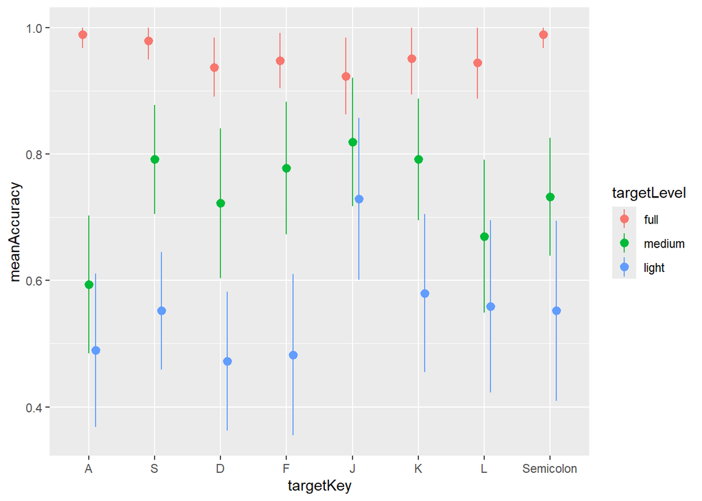

```r
pd <- position_dodge(width = 0.3)
log_threelevel_accuracy_summary %>% ggplot(
  aes(
    x = targetKey,
    y = meanAccuracy,
    ymin = lowCIAccuracy,
    ymax = highCIAccuracy,
    color = targetLevel
  )
) +
  geom_pointrange(position = pd)
```

```r
log_threelevel_accuracy_summary_level <- log_threelevel_accuracy  %>%
  group_by(targetLevel) %>%
  summarize(
    meanAccuracy = accuracy_ave %>% mean(na.rm=TRUE),
    lowCIAccuracy = ci(accuracy_ave)[2] %>% pmax(0),
    highCIAccuracy = ci(accuracy_ave)[3] %>% pmin(1),
    sdAccuracy = ci(accuracy_ave)[4],
    stdAccuracy = sd(accuracy_ave)) %>%
  ungroup() %>%
  arrange(targetLevel)

log_threelevel_accuracy_summary_level
```

```
## # A tibble: 3 × 6
##   targetLevel meanAccuracy lowCIAccuracy highCIAccuracy sdAccuracy stdAccuracy
##   <fct>              <dbl>         <dbl>          <dbl>      <dbl>       <dbl>
## 1 full               0.958         0.943          0.973    0.00769       0.107
## 2 medium             0.737         0.701          0.773    0.0182        0.253
## 3 light              0.552         0.510          0.595    0.0215        0.298
```

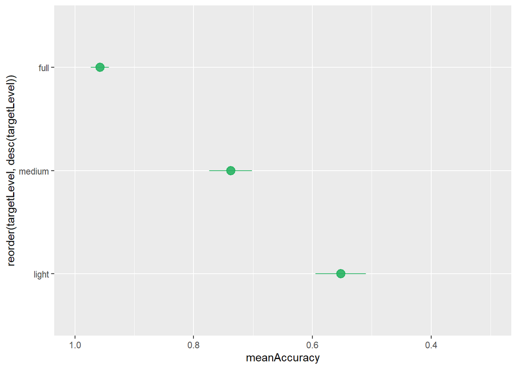

```r
# line + dot (levels)
threelevel_accuracy_level <- ggplot(log_threelevel_accuracy_summary_level) +
  geom_pointrange( aes(x=reorder(targetLevel, desc(targetLevel)), y=meanAccuracy, ymin=lowCIAccuracy, ymax=highCIAccuracy), colour="#28b463", alpha=0.9, size=0.8) +
  scale_y_reverse(lim=c(1.0,0.3)) +
  coord_flip()

threelevel_accuracy_level
```

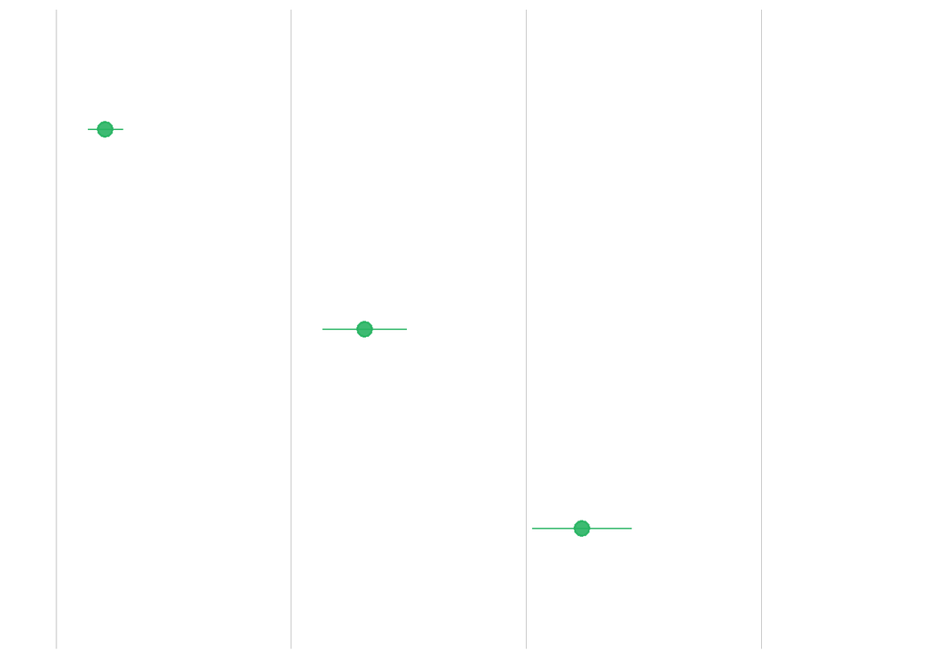

```r
threelevel_accuracy_level + theme( # remove the vertical grid lines
          panel.background = element_blank(),
          panel.grid.major.y = element_blank() ,
          # explicitly set the horizontal lines (or they will disappear too)
          panel.grid.major.x = element_line( size=.1, color="gray" ),
          axis.title.x = element_blank(),
          axis.text.x=element_blank(),
          axis.ticks.x = element_blank(),
          axis.title.y = element_blank(),
          axis.text.y=element_blank(),
          axis.ticks.y = element_blank()
    )
```

```r
ggsave("3level_accuracy_level.pdf", width = 4, height = 3)

log_threelevel_accuracy_summary_key <- log_threelevel_accuracy  %>%
  group_by(targetKey) %>%
  summarize(
    meanAccuracy = accuracy_ave %>% mean(na.rm=TRUE),
    lowCIAccuracy = ci(accuracy_ave)[2] %>% pmax(0),
    highCIAccuracy = ci(accuracy_ave)[3] %>% pmin(1),
    sdAccuracy = ci(accuracy_ave)[4],
    stdAccuracy = sd(accuracy_ave)) %>%
  ungroup() %>%
  arrange(targetKey)

log_threelevel_accuracy_summary_key
```

```
## # A tibble: 8 × 6
##   targetKey meanAccuracy lowCIAccuracy highCIAccuracy sdAccuracy stdAccuracy
##   <fct>            <dbl>         <dbl>          <dbl>      <dbl>       <dbl>
## 1 A                0.691         0.618          0.764     0.0365       0.310
## 2 S                0.774         0.716          0.833     0.0293       0.249
## 3 D                0.711         0.641          0.780     0.0350       0.297
## 4 F                0.736         0.665          0.807     0.0355       0.301
## 5 J                0.824         0.766          0.882     0.0292       0.248
## 6 K                0.774         0.710          0.838     0.0322       0.273
## 7 L                0.725         0.653          0.796     0.0359       0.304
## 8 Semicolon        0.758         0.689          0.827     0.0346       0.294
```

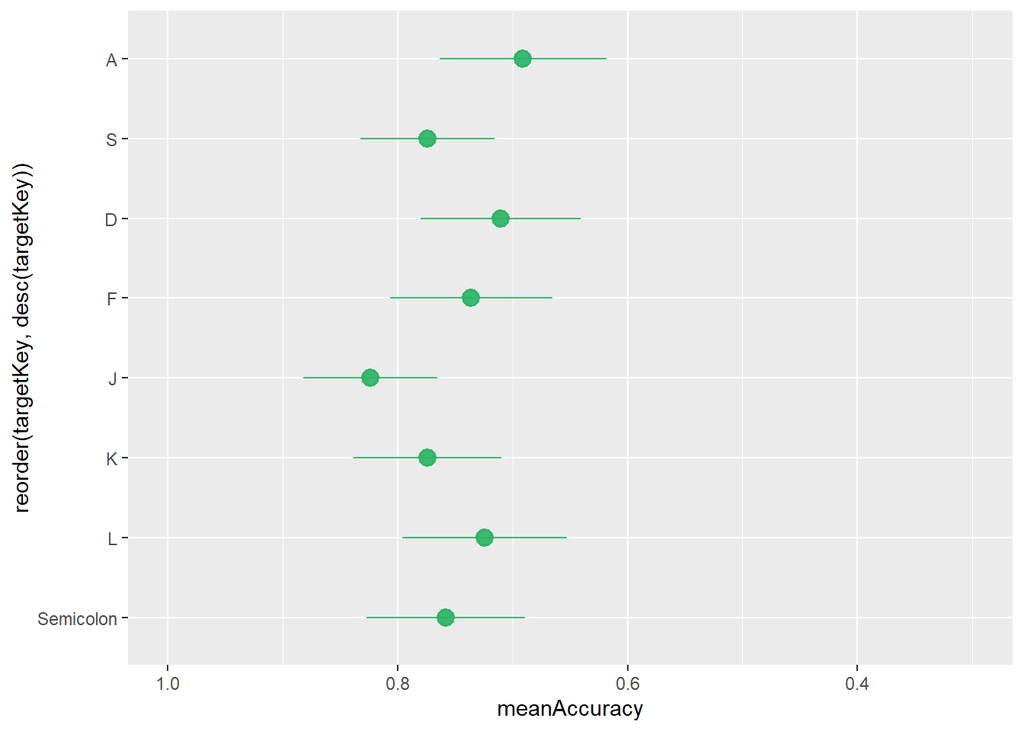

```r
# line + dot (key)
threelevel_accuracy_key <- ggplot(log_threelevel_accuracy_summary_key) +
  geom_pointrange( aes(x=reorder(targetKey, desc(targetKey)), y=meanAccuracy, ymin=lowCIAccuracy, ymax=highCIAccuracy), colour="#28b463", alpha=0.9, size=0.8) +
  scale_y_reverse(lim=c(1.0,0.3)) +
  coord_flip()

threelevel_accuracy_key
```

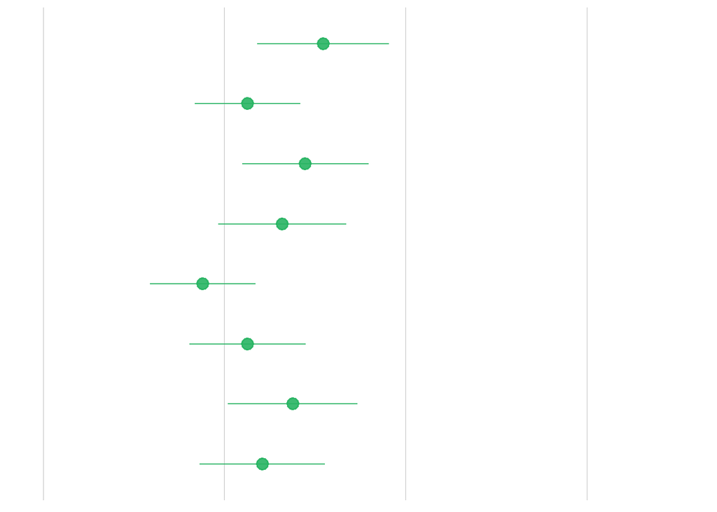

```r
threelevel_accuracy_key + theme( # remove the vertical grid lines
          panel.background = element_blank(),
          panel.grid.major.y = element_blank() ,
          # explicitly set the horizontal lines (or they will disappear too)
          panel.grid.major.x = element_line( size=.1, color="gray" ),
          axis.title.x = element_blank(),
          axis.text.x=element_blank(),
          axis.ticks.x = element_blank(),
          axis.title.y = element_blank(),
          axis.text.y=element_blank(),
          axis.ticks.y = element_blank()
    )
```

```r
ggsave("3level_accuracy_key.pdf", width = 4, height = 8)
```

#### accuracy analysis

```r
m = aov(accuracy_ave ~ targetLevel*targetKey, data=log_threelevel_accuracy) # make anova-type linear model
shapiro.test(residuals(m))
```

```
##
##  Shapiro-Wilk normality test
##
## data:  residuals(m)
## W = 0.96301, p-value = 7.383e-11
```

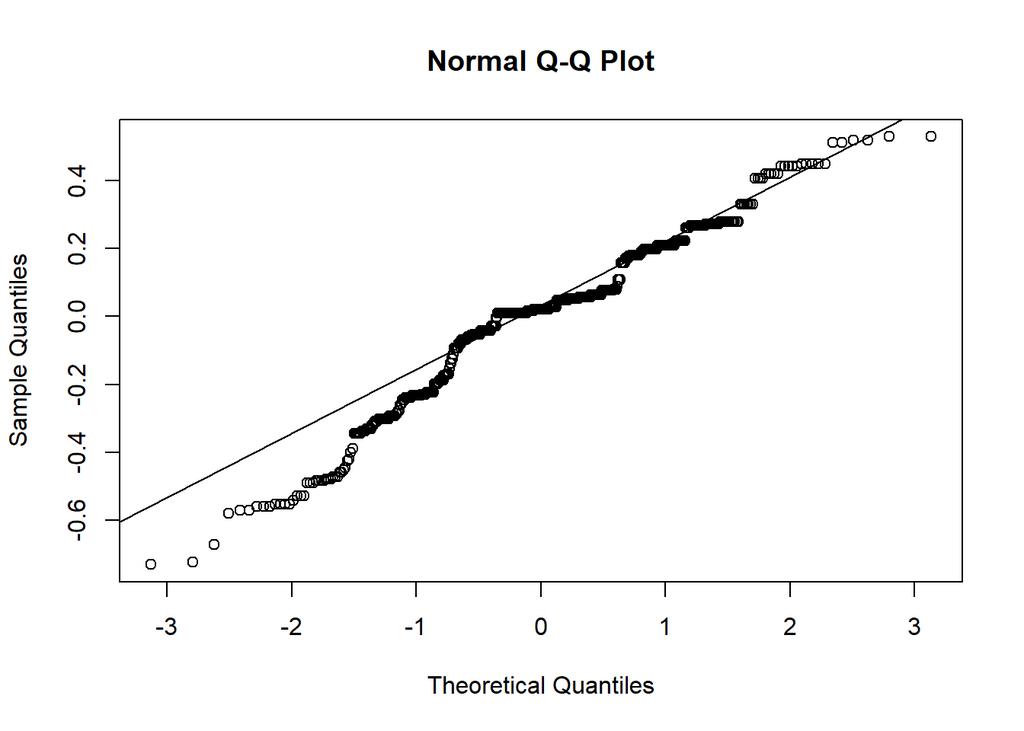

```r
qqnorm(residuals(m)); qqline(residuals(m)) # Q-Q plot
```

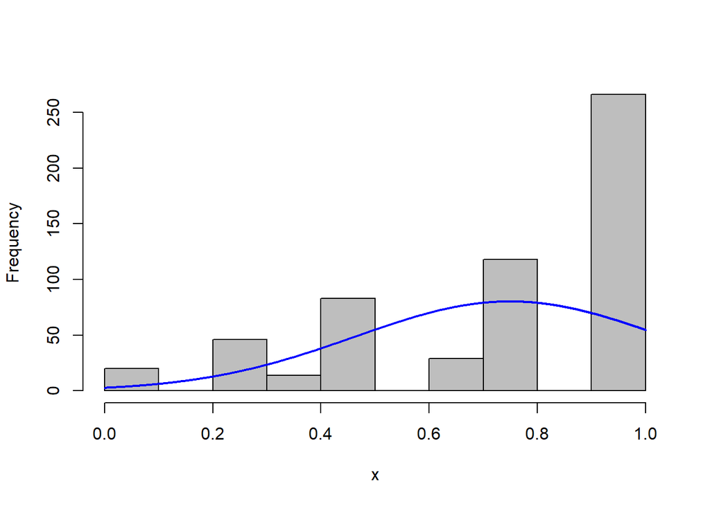

```r
plotNormalHistogram(log_threelevel_accuracy$accuracy_ave)
```

```r
library(lme4)
library(lmerTest)
library(car)

log_threelevel_accuracy$id = factor(log_threelevel_accuracy$id)
contrasts(log_threelevel_accuracy$targetLevel) <-"contr.sum"
contrasts(log_threelevel_accuracy$targetKey) <-"contr.sum"
m = glmer(accuracy_ave ~ targetLevel*targetKey + (1|id), data=log_threelevel_accuracy, family=poisson)
# use family=quasipoissonif overdispersion
Anova(m, type=3)
```

```
## Analysis of Deviance Table (Type III Wald chisquare tests)
##
## Response: accuracy_ave
##                         Chisq Df Pr(>Chisq)
## (Intercept)            0.0479  1     0.8267
## targetLevel           21.2103  2  2.479e-05 ***
## targetKey              0.1096  7     1.0000
## targetLevel:targetKey  2.1952 14     0.9999
## ---
## Signif. codes:  0 '***' 0.001 '**' 0.01 '*' 0.05 '.' 0.1 ' ' 1
```

```r
library(multcomp) # for glht
library(emmeans) # for emm, emmeans
summary(glht(m, emm(pairwise ~ targetLevel)), test=adjusted(type="holm"))
```

```
## NOTE: Results may be misleading due to involvement in interactions
```

```
##
##   Simultaneous Tests for General Linear Hypotheses
##
## Fit: glmer(formula = accuracy_ave ~ targetLevel * targetKey + (1 |
##     id), data = log_threelevel_accuracy, family = poisson)
##
## Linear Hypotheses:
##                     Estimate Std. Error z value Pr(>|z|)
## full - medium == 0    0.2662     0.1121   2.374   0.0352 *
## full - light == 0     0.5596     0.1226   4.564 1.51e-05 ***
## medium - light == 0   0.2935     0.1293   2.269   0.0352 *
## ---
## Signif. codes:  0 '***' 0.001 '**' 0.01 '*' 0.05 '.' 0.1 ' ' 1
## (Adjusted p values reported -- holm method)
```

Main effect on targetLevel: Full has higher accuracy then medium and light; Medium has higher accuracy then light.

#### time

```r
log_threeLevel_time <- trial_log_filtered%>%
  filter(levelCounts == c("3")) %>%
  group_by(id, targetLevel, targetKey) %>%
  summarize(
    time_ave = sum(time) / n(),
    n_trials = n()
  ) %>%
  ungroup() %>%
  arrange(id, targetLevel, targetKey)
log_threeLevel_time_summary <- log_threeLevel_time  %>%
  group_by(targetLevel, targetKey) %>%
  summarize(
    meanTime = time_ave %>% mean(na.rm=TRUE),
    lowCITime = ci(time_ave)[2] %>% pmax(0),
    highCITime = ci(time_ave)[3],
    sdTime = ci(time_ave)[4],
    stdTime = sd(time_ave)) %>%
  ungroup() %>%
  arrange(targetLevel, targetKey)
log_threeLevel_time_summary
```

```
## # A tibble: 24 × 7
##    targetLevel targetKey meanTime lowCITime highCITime sdTime stdTime
##    <fct>       <fct>        <dbl>     <dbl>      <dbl>  <dbl>   <dbl>
##  1 full        A            1097.     1005.      1190.   44.7    219.
##  2 full        S            1205.     1094.      1316.   53.6    263.
##  3 full        D            1286.     1197.      1375.   42.9    210.
##  4 full        F            1248.     1141.      1355.   51.6    253.
##  5 full        J            1308.     1189.      1427.   57.4    281.
##  6 full        K            1481.     1345.      1618.   65.9    323.
##  7 full        L            1410.     1276.      1544.   64.9    318.
##  8 full        Semicolon    1259.     1154.      1363.   50.5    247.
##  9 medium      A            1313.     1195.      1431.   57.1    279.
## 10 medium      S            1244.     1109.      1379.   65.1    319.
## # ℹ 14 more rows
```

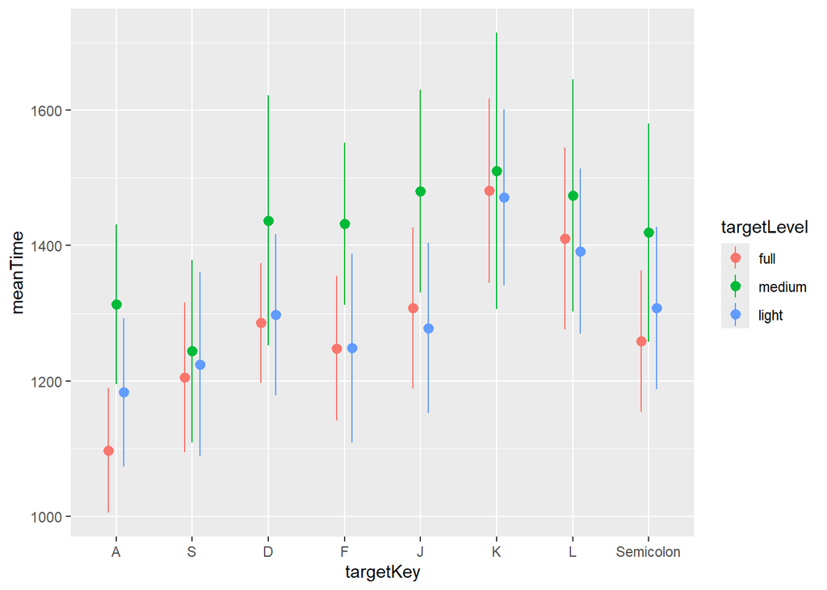

```r
pd <- position_dodge(width = 0.3)
log_threeLevel_time_summary %>% ggplot(
  aes(
    x = targetKey,
    y = meanTime,
    ymin = lowCITime,
    ymax = highCITime,
    color = targetLevel
  )
) +
  geom_pointrange(position = pd)
```

```r
log_threeLevel_time_summary_level <- log_threeLevel_time  %>%
  group_by(targetLevel) %>%
  summarize(
    meanTime = time_ave %>% mean(na.rm=TRUE),
    lowCITime = ci(time_ave)[2] %>% pmax(0),
    highCITime = ci(time_ave)[3],
    sdTime = ci(time_ave)[4],
    stdTime = sd(time_ave)) %>%
  ungroup() %>%
  arrange(targetLevel)

log_threeLevel_time_summary_level
```

```
## # A tibble: 3 × 6
##   targetLevel meanTime lowCITime highCITime sdTime stdTime
##   <fct>          <dbl>     <dbl>      <dbl>  <dbl>   <dbl>
## 1 full           1287.     1246.      1327.   20.6    285.
## 2 medium         1414.     1360.      1467.   27.2    378.
## 3 light          1300.     1257.      1344.   22.0    305.
```

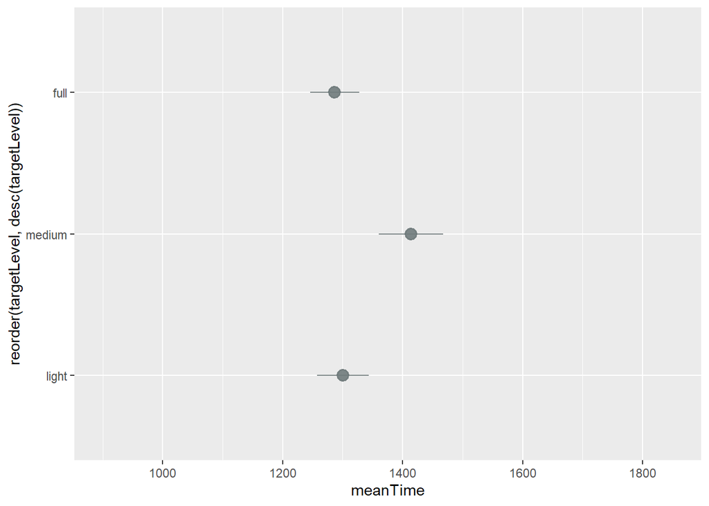

```r
# line + dot (levels)
threelevel_time_level <- ggplot(log_threeLevel_time_summary_level) +
  geom_pointrange( aes(x=reorder(targetLevel, desc(targetLevel)), y=meanTime, ymin=lowCITime, ymax=highCITime), colour="#707b7c", alpha=0.9, size=0.8) +
  scale_y_continuous(lim=c(900,1850)) +
  coord_flip()

threelevel_time_level
```

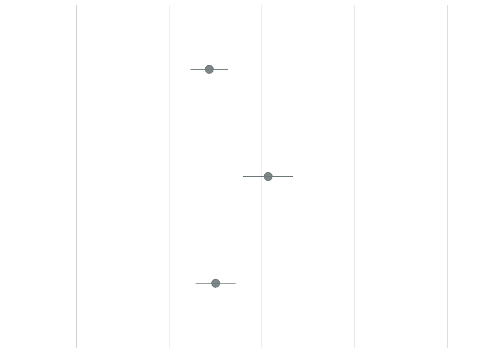

```r
threelevel_time_level + theme( # remove the vertical grid lines
          panel.background = element_blank(),
          panel.grid.major.y = element_blank() ,
          # explicitly set the horizontal lines (or they will disappear too)
          panel.grid.major.x = element_line( size=.1, color="gray" ),
          axis.title.x = element_blank(),
          axis.text.x=element_blank(),
          axis.ticks.x = element_blank(),
          axis.title.y = element_blank(),
          axis.text.y=element_blank(),
          axis.ticks.y = element_blank()
    )
```

```r
ggsave("3level_time_level.pdf", width = 4, height = 3)


log_threeLevel_time_summary_key <- log_threeLevel_time  %>%
  group_by(targetKey) %>%
  summarize(
    meanTime = time_ave %>% mean(na.rm=TRUE),
    lowCITime = ci(time_ave)[2] %>% pmax(0),
    highCITime = ci(time_ave)[3],
    sdTime = ci(time_ave)[4],
    stdTime = sd(time_ave)) %>%
  ungroup() %>%
  arrange(targetKey)

log_threeLevel_time_summary_key
```

```
## # A tibble: 8 × 6
##   targetKey meanTime lowCITime highCITime sdTime stdTime
##   <fct>        <dbl>     <dbl>      <dbl>  <dbl>   <dbl>
## 1 A            1198.     1135.      1260.   31.3    265.
## 2 S            1225.     1154.      1295.   35.2    298.
## 3 D            1340.     1263.      1417.   38.6    327.
## 4 F            1310.     1239.      1380.   35.3    300.
## 5 J            1355.     1280.      1431.   37.9    322.
## 6 K            1488.     1400.      1576.   44.2    375.
## 7 L            1425.     1346.      1505.   39.9    339.
## 8 Semicolon    1328.     1255.      1402.   36.9    313.
```

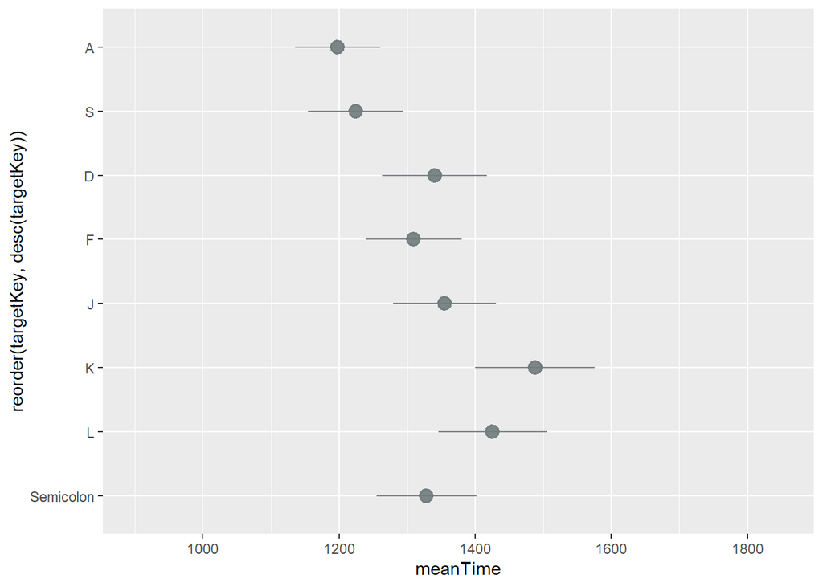

```r
# line + dot (key)
threelevel_time_key <- ggplot(log_threeLevel_time_summary_key) +
  geom_pointrange( aes(x=reorder(targetKey, desc(targetKey)), y=meanTime, ymin=lowCITime, ymax=highCITime), colour="#707b7c", alpha=0.9, size=0.8) +
  scale_y_continuous(lim=c(900,1850)) +
  coord_flip()

threelevel_time_key
```

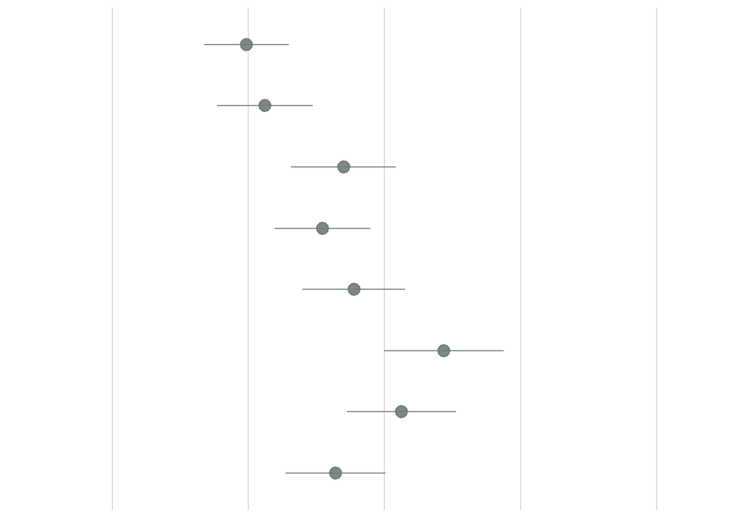

```r
threelevel_time_key + theme( # remove the vertical grid lines
          panel.background = element_blank(),
          panel.grid.major.y = element_blank() ,
          # explicitly set the horizontal lines (or they will disappear too)
          panel.grid.major.x = element_line( size=.1, color="gray" ),
          axis.title.x = element_blank(),
          axis.text.x=element_blank(),
          axis.ticks.x = element_blank(),
          axis.title.y = element_blank(),
          axis.text.y=element_blank(),
          axis.ticks.y = element_blank()
    )
```

```r
ggsave("3level_time_key.pdf", width = 4, height = 8)
```

#### time

```r
m = aov(time_ave ~ targetLevel*targetKey, data=log_threeLevel_time) # make anova-type linear model
shapiro.test(residuals(m))
```

```
##
##  Shapiro-Wilk normality test
##
## data:  residuals(m)
## W = 0.94835, p-value = 2.689e-13
```

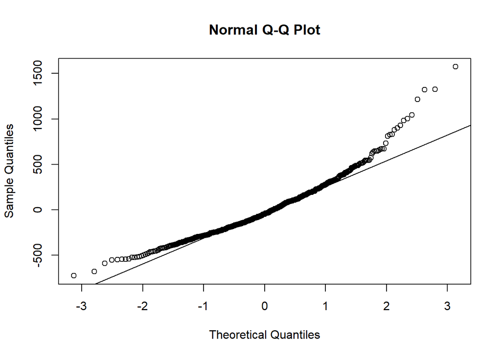

```r
qqnorm(residuals(m)); qqline(residuals(m)) # Q-Q plot
```

```r
library(rcompanion)
log_threeLevel_time$time_ave_trans = transformTukey(log_threeLevel_time$time_ave)
```

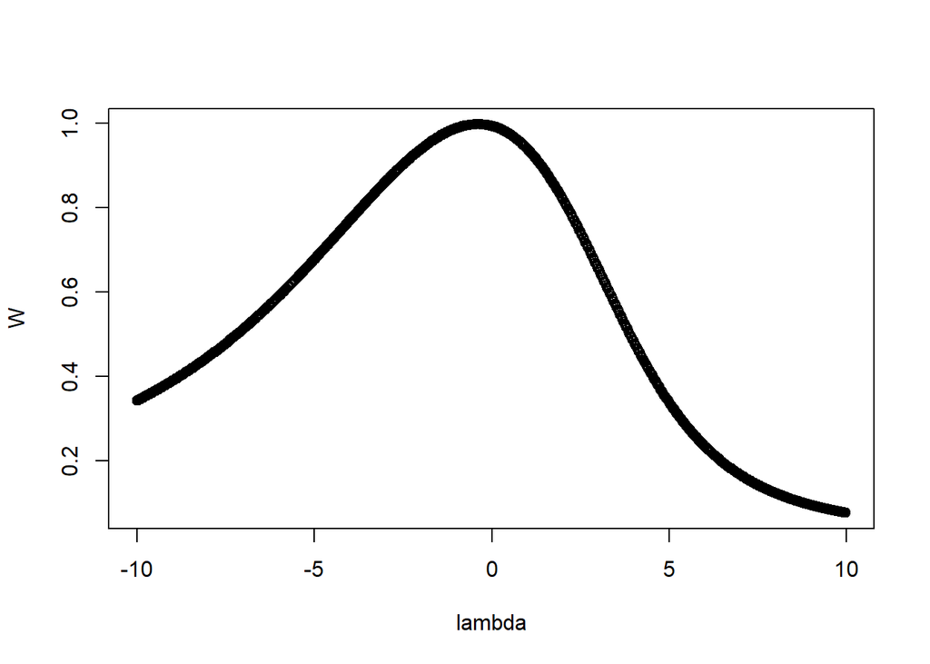

```
##
##     lambda      W Shapiro.p.value
## 384 -0.425 0.9979          0.7067
##
## if (lambda >  0){TRANS = x ^ lambda}
## if (lambda == 0){TRANS = log(x)}
## if (lambda <  0){TRANS = -1 * x ^ lambda}
```

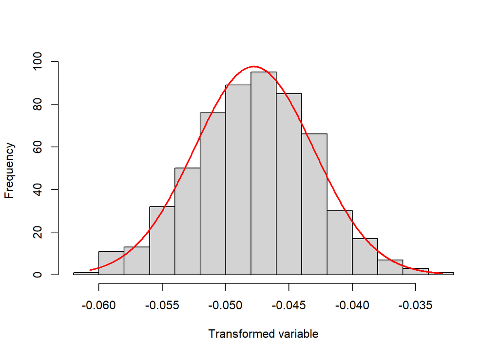

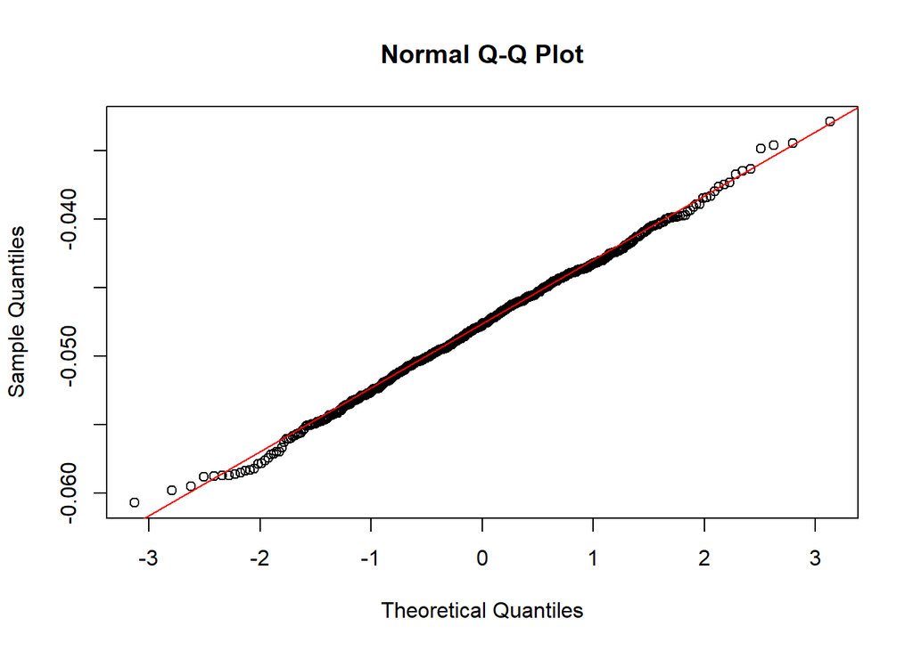

```r
m = aov(time_ave_trans ~ targetLevel*targetKey, data=log_threeLevel_time) # make anova-type linear model
shapiro.test(residuals(m))
```

```
##
##  Shapiro-Wilk normality test
##
## data:  residuals(m)
## W = 0.99797, p-value = 0.729
```

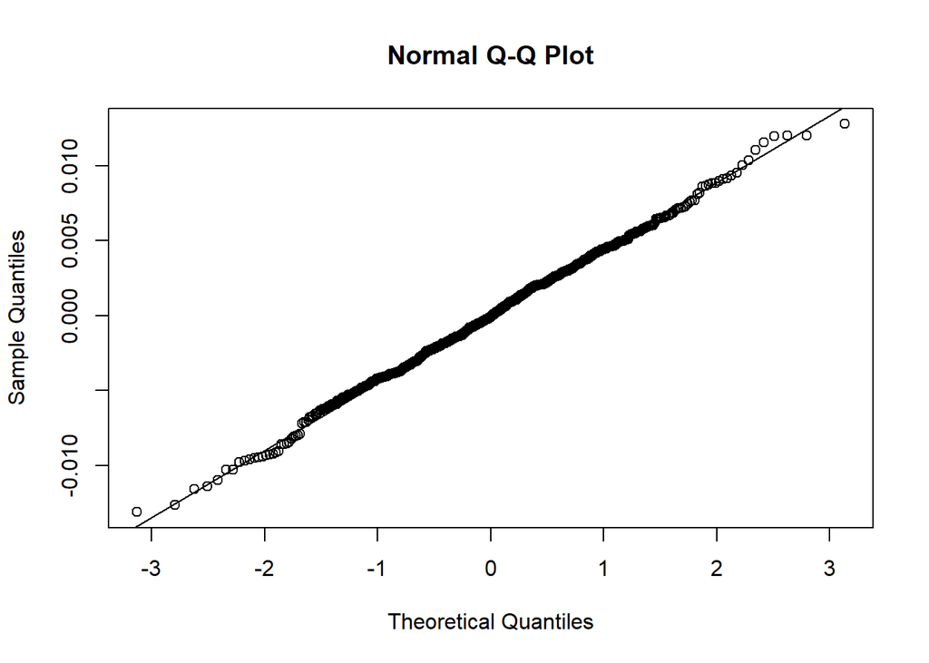

```r
qqnorm(residuals(m)); qqline(residuals(m)) # Q-Q plot
```

```r
library(ez) # for ezANOVA
log_threeLevel_time$id = factor(log_threeLevel_time$id)
m = ezANOVA(dv=time_ave_trans, within=c(targetLevel,targetKey), wid=id, data=log_threeLevel_time)
m$Mauchly # p<.05 indicates a sphericity violation
```

```
##                  Effect           W          p p<.05
## 2           targetLevel 0.725868098 0.02947371     *
## 3             targetKey 0.122180614 0.02850259     *
## 4 targetLevel:targetKey 0.001656197 0.27045675
```

```r
m$Sphericity
```

```
##                  Effect       GGe        p[GG] p[GG]<.05       HFe        p[HF]
## 2           targetLevel 0.7848481 1.298855e-04         * 0.8322959 8.935247e-05
## 3             targetKey 0.6520595 5.625501e-12         * 0.8333727 1.038262e-14
## 4 targetLevel:targetKey 0.5651073 5.211811e-02           0.8894005 2.433200e-02
##   p[HF]<.05
## 2         *
## 3         *
## 4         *
```

```r
m$ANOVA # use if no violation
```

```
##                  Effect DFn DFd         F            p p<.05        ges
## 2           targetLevel   2  46 13.528935 2.393806e-05     * 0.02893128
## 3             targetKey   7 161 17.596955 3.246600e-17     * 0.08342811
## 4 targetLevel:targetKey  14 322  1.978475 1.890375e-02     * 0.01683490
```

```r
pairwise.t.test(log_threeLevel_time$time_ave_trans, log_threeLevel_time$targetLevel, paired=TRUE, p.adjust="holm")
```

```
##
##  Pairwise comparisons using paired t tests
##
## data:  log_threeLevel_time$time_ave_trans and log_threeLevel_time$targetLevel
##
##        full    medium
## medium 2.3e-07 -
## light  0.68    2.3e-07
##
## P value adjustment method: holm
```

```r
pairwise.t.test(log_threeLevel_time$time_ave_trans, log_threeLevel_time$targetKey, paired=TRUE, p.adjust="holm")
```

```
##
##  Pairwise comparisons using paired t tests
##
## data:  log_threeLevel_time$time_ave_trans and log_threeLevel_time$targetKey
##
##           A       S       D       F       J       K       L
## S         1.00000 -       -       -       -       -       -
## D         1.0e-04 0.00406 -       -       -       -       -
## F         0.00158 0.03922 1.00000 -       -       -       -
## J         0.00038 0.00068 1.00000 1.00000 -       -       -
## K         4.2e-11 1.2e-08 0.00012 0.00017 0.00719 -       -
## L         7.1e-11 5.6e-08 0.01819 0.00420 0.19844 0.68121 -
## Semicolon 0.00017 0.00153 1.00000 1.00000 1.00000 0.00122 0.00893
##
## P value adjustment method: holm
```

```r
pairwise.t.test(log_threeLevel_time$time_ave_trans, interaction(log_threeLevel_time$targetKey, log_threeLevel_time$targetLevel), paired=TRUE, p.adjust="holm")
```

```
##
##  Pairwise comparisons using paired t tests
##
## data:  log_threeLevel_time$time_ave_trans and interaction(log_threeLevel_time$targetKey, log_threeLevel_time$targetLevel)
##
##                  A.full  S.full  D.full  F.full  J.full  K.full  L.full
## S.full           1.00000 -       -       -       -       -       -
## D.full           0.00386 1.00000 -       -       -       -       -
## F.full           0.22124 1.00000 1.00000 -       -       -       -
## J.full           0.48184 1.00000 1.00000 1.00000 -       -       -
## K.full           8.1e-06 0.06516 0.26557 0.42194 1.00000 -       -
## L.full           0.00018 0.15986 1.00000 0.42194 1.00000 1.00000 -
## Semicolon.full   0.08036 1.00000 1.00000 1.00000 1.00000 0.45089 0.63782
## A.medium         0.00213 1.00000 1.00000 1.00000 1.00000 1.00000 1.00000
## S.medium         1.00000 1.00000 1.00000 1.00000 1.00000 0.40851 0.72116
## D.medium         0.00032 0.42964 1.00000 0.50552 1.00000 1.00000 1.00000
## F.medium         2.2e-05 0.02498 1.00000 0.24606 1.00000 1.00000 1.00000
## J.medium         0.00019 0.03502 0.22155 0.03973 1.00000 1.00000 1.00000
## K.medium         5.8e-05 0.00239 1.00000 0.18407 1.00000 1.00000 1.00000
## L.medium         2.7e-05 0.00192 1.00000 0.06768 1.00000 1.00000 1.00000
## Semicolon.medium 0.00022 0.08532 1.00000 1.00000 1.00000 1.00000 1.00000
## A.light          1.00000 1.00000 1.00000 1.00000 1.00000 0.00262 0.00390
## S.light          1.00000 1.00000 1.00000 1.00000 1.00000 0.35214 0.98694
## D.light          0.02773 1.00000 1.00000 1.00000 1.00000 0.13436 1.00000
## F.light          1.00000 1.00000 1.00000 1.00000 1.00000 0.43536 1.00000
## J.light          0.68098 1.00000 1.00000 1.00000 1.00000 1.00000 1.00000
## K.light          0.00034 0.13066 1.00000 0.08591 1.00000 1.00000 1.00000
## L.light          0.00139 0.23360 1.00000 1.00000 1.00000 1.00000 1.00000
## Semicolon.light  0.00584 1.00000 1.00000 1.00000 1.00000 1.00000 1.00000
##                  Semicolon.full A.medium S.medium D.medium F.medium J.medium
## S.full           -              -        -        -        -        -
## D.full           -              -        -        -        -        -
## F.full           -              -        -        -        -        -
## J.full           -              -        -        -        -        -
## K.full           -              -        -        -        -        -
## L.full           -              -        -        -        -        -
## Semicolon.full   -              -        -        -        -        -
## A.medium         1.00000        -        -        -        -        -
## S.medium         1.00000        1.00000  -        -        -        -
## D.medium         1.00000        1.00000  0.19364  -        -        -
```

[output cut: 48 more lines]

```
## F.medium         -       -       -       -
## J.medium         -       -       -       -
## K.medium         -       -       -       -
## L.medium         -       -       -       -
## Semicolon.medium -       -       -       -
## A.light          -       -       -       -
## S.light          -       -       -       -
## D.light          -       -       -       -
## F.light          -       -       -       -
## J.light          1.00000 -       -       -
## K.light          0.06353 0.22124 -       -
## L.light          1.00000 1.00000 1.00000 -
## Semicolon.light  1.00000 1.00000 1.00000 1.00000
##
## P value adjustment method: holm
```

```r
# library(ARTool)
# log_threeLevel_time$id = factor(log_threeLevel_time$id) # Subject id must be nominal
# m = art(time_ave ~ targetLevel*targetKey + (1|id), data=log_threeLevel_time) # subjects (S) as random effect
# anova(m)
#
# art.con(m, "targetLevel")
# art.con(m, "targetKey")
# art.con(m, "targetLevel:targetKey")
```

Main effect on targetLevel: full and light is faster than medium

Main effect on targetKey: (AS) faster than (DFJKL;), (DF;) faster than (KL), J faster than K

Main interaction: For full, A faster than DKL

For medium, S faster than FJKL

For light, A faster than KL

### 4 level

#### accuracy

```r
log_fourlevel_accuracy <- trial_log_filtered %>%
  filter(levelCounts == c("4")) %>%
  group_by(id, targetLevel, targetKey) %>%
  summarize(
    accuracy_ave = sum(isSuccessful) / n(),
    n_trials = n()
  ) %>%
  ungroup() %>%
  arrange(id, targetLevel, targetKey)
log_fourlevel_accuracy_summary <- log_fourlevel_accuracy  %>%
  group_by(targetLevel, targetKey) %>%
  summarize(
    meanAccuracy = accuracy_ave %>% mean(na.rm=TRUE),
    lowCIAccuracy = ci(accuracy_ave)[2] %>% pmax(0),
    highCIAccuracy = ci(accuracy_ave)[3] %>% pmin(1),
    sdAccuracy = ci(accuracy_ave)[4],
    stdAccuracy = sd(accuracy_ave)) %>%
  ungroup() %>%
  arrange(targetLevel, targetKey)
log_fourlevel_accuracy_summary
```

```
## # A tibble: 32 × 7
##    targetLevel targetKey meanAccuracy lowCIAccuracy highCIAccuracy sdAccuracy
##    <fct>       <fct>            <dbl>         <dbl>          <dbl>      <dbl>
##  1 full        A                0.990         0.968          1         0.0104
##  2 full        S                0.969         0.933          1         0.0172
##  3 full        D                0.948         0.904          0.992     0.0212
##  4 full        F                0.976         0.941          1         0.0170
##  5 full        J                0.948         0.894          1         0.0260
##  6 full        K                0.965         0.925          1         0.0194
##  7 full        L                0.951         0.888          1         0.0305
##  8 full        Semicolon        0.938         0.881          0.994     0.0271
##  9 mediumHigh  A                0.361         0.247          0.476     0.0553
## 10 mediumHigh  S                0.354         0.242          0.466     0.0541
## # ℹ 22 more rows
## # ℹ 1 more variable: stdAccuracy <dbl>
```

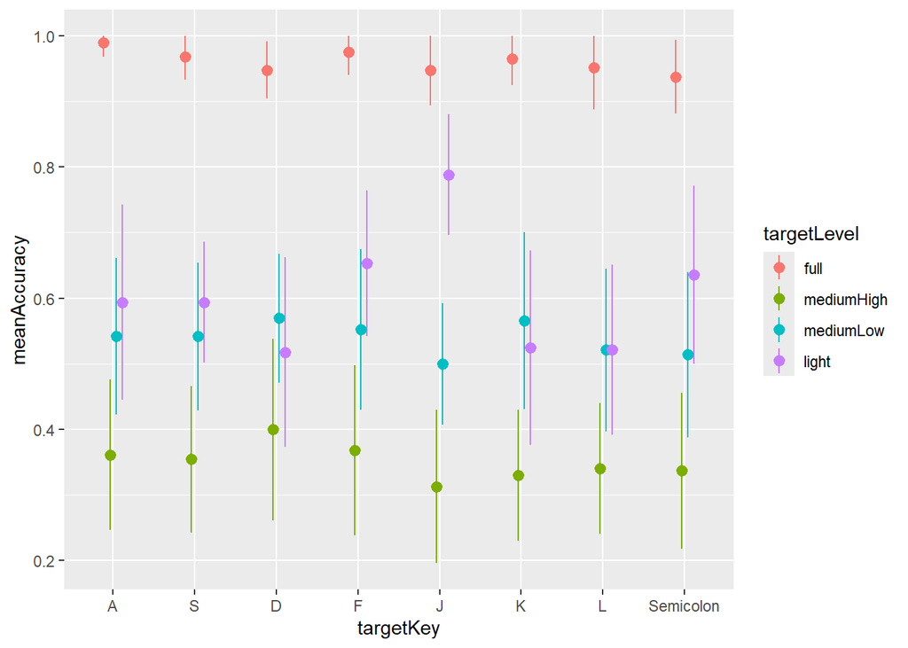

```r
pd <- position_dodge(width = 0.3)
log_fourlevel_accuracy_summary %>% ggplot(
  aes(
    x = targetKey,
    y = meanAccuracy,
    ymin = lowCIAccuracy,
    ymax = highCIAccuracy,
    color = targetLevel
  )
) +
  geom_pointrange(position = pd)
```

```r
log_fourlevel_accuracy_summary_level <- log_fourlevel_accuracy  %>%
  group_by(targetLevel) %>%
  summarize(
    meanAccuracy = accuracy_ave %>% mean(na.rm=TRUE),
    lowCIAccuracy = ci(accuracy_ave)[2] %>% pmax(0),
    highCIAccuracy = ci(accuracy_ave)[3] %>% pmin(1),
    sdAccuracy = ci(accuracy_ave)[4],
    stdAccuracy = sd(accuracy_ave)) %>%
  ungroup() %>%
  arrange(targetLevel)

log_fourlevel_accuracy_summary_level
```

```
## # A tibble: 4 × 6
##   targetLevel meanAccuracy lowCIAccuracy highCIAccuracy sdAccuracy stdAccuracy
##   <fct>              <dbl>         <dbl>          <dbl>      <dbl>       <dbl>
## 1 full               0.961         0.945          0.976    0.00771       0.107
## 2 mediumHigh         0.350         0.311          0.389    0.0197        0.273
## 3 mediumLow          0.538         0.499          0.577    0.0197        0.273
## 4 light              0.603         0.559          0.647    0.0222        0.308
```

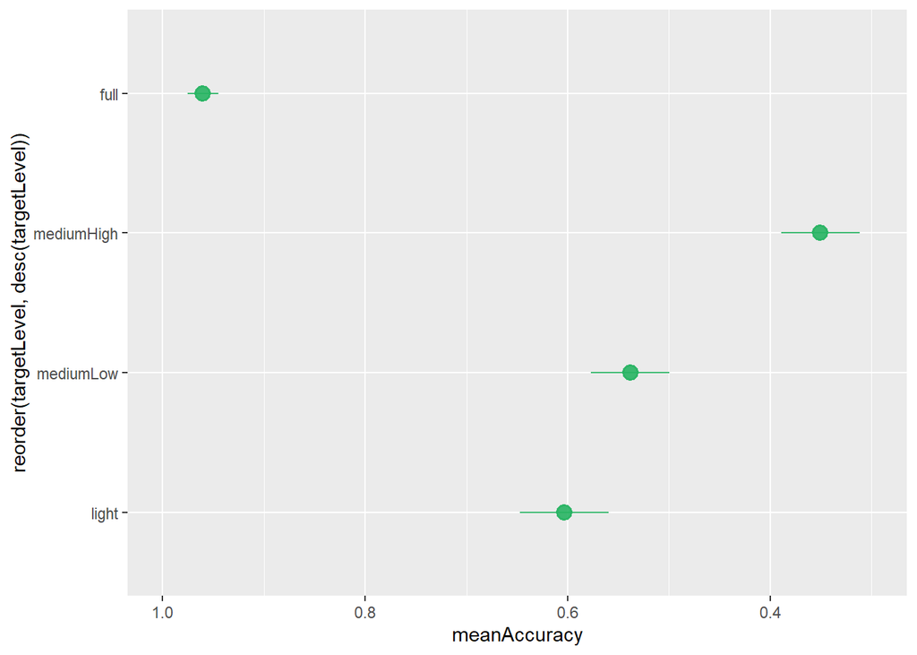

```r
# line + dot (levels)
fourlevel_accuracy_level <- ggplot(log_fourlevel_accuracy_summary_level) +
  geom_pointrange( aes(x=reorder(targetLevel, desc(targetLevel)), y=meanAccuracy, ymin=lowCIAccuracy, ymax=highCIAccuracy), colour="#28b463", alpha=0.9, size=0.8) +
  scale_y_reverse(lim=c(1.0,0.3)) +
  coord_flip()

fourlevel_accuracy_level
```

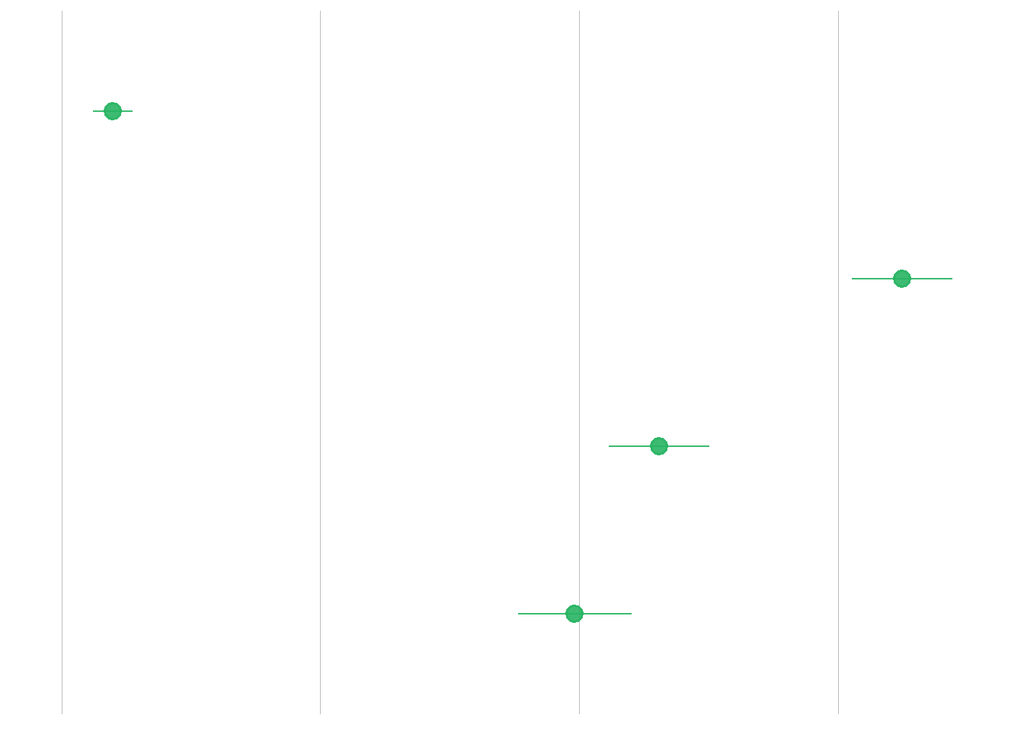

```r
fourlevel_accuracy_level + theme( # remove the vertical grid lines
          panel.background = element_blank(),
          panel.grid.major.y = element_blank() ,
          # explicitly set the horizontal lines (or they will disappear too)
          panel.grid.major.x = element_line( size=.1, color="gray" ),
          axis.title.x = element_blank(),
          axis.text.x=element_blank(),
          axis.ticks.x = element_blank(),
          axis.title.y = element_blank(),
          axis.text.y=element_blank(),
          axis.ticks.y = element_blank()
    )
```

```r
ggsave("4level_accuracy_level.pdf", width = 4, height = 4)

log_fourlevel_accuracy_summary_key <- log_fourlevel_accuracy  %>%
  group_by(targetKey) %>%
  summarize(
    meanAccuracy = accuracy_ave %>% mean(na.rm=TRUE),
    lowCIAccuracy = ci(accuracy_ave)[2] %>% pmax(0),
    highCIAccuracy = ci(accuracy_ave)[3] %>% pmin(1),
    sdAccuracy = ci(accuracy_ave)[4],
    stdAccuracy = sd(accuracy_ave)) %>%
  ungroup() %>%
  arrange(targetKey)

log_fourlevel_accuracy_summary_key
```

```
## # A tibble: 8 × 6
##   targetKey meanAccuracy lowCIAccuracy highCIAccuracy sdAccuracy stdAccuracy
##   <fct>            <dbl>         <dbl>          <dbl>      <dbl>       <dbl>
## 1 A                0.622         0.551          0.692     0.0355       0.348
## 2 S                0.615         0.551          0.678     0.0319       0.313
## 3 D                0.609         0.540          0.677     0.0343       0.336
## 4 F                0.637         0.570          0.705     0.0340       0.333
## 5 J                0.637         0.571          0.704     0.0334       0.328
## 6 K                0.596         0.525          0.668     0.0359       0.352
## 7 L                0.583         0.515          0.652     0.0344       0.337
## 8 Semicolon        0.606         0.536          0.676     0.0351       0.344
```

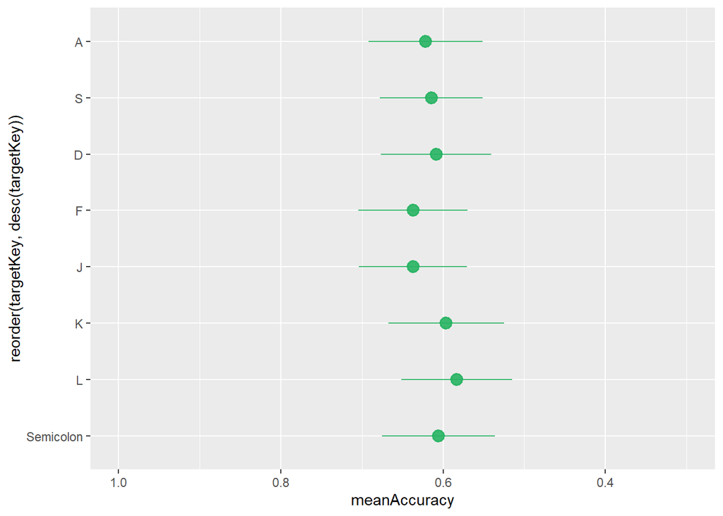

```r
# line + dot (key)
fourlevel_accuracy_key <- ggplot(log_fourlevel_accuracy_summary_key) +
  geom_pointrange( aes(x=reorder(targetKey, desc(targetKey)), y=meanAccuracy, ymin=lowCIAccuracy, ymax=highCIAccuracy), colour="#28b463", alpha=0.9, size=0.8) +
  scale_y_reverse(lim=c(1.0,0.3)) +
  coord_flip()

fourlevel_accuracy_key
```

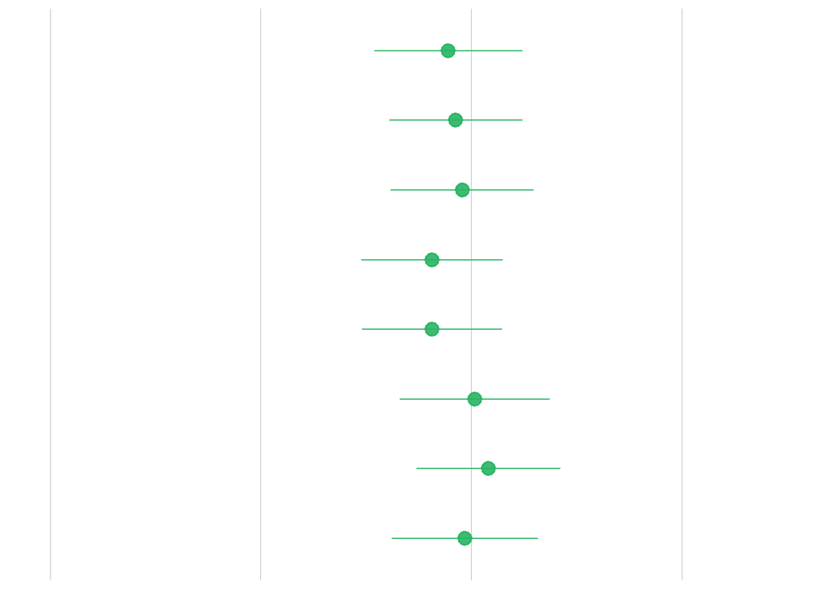

```r
fourlevel_accuracy_key + theme( # remove the vertical grid lines
          panel.background = element_blank(),
          panel.grid.major.y = element_blank() ,
          # explicitly set the horizontal lines (or they will disappear too)
          panel.grid.major.x = element_line( size=.1, color="gray" ),
          axis.title.x = element_blank(),
          axis.text.x=element_blank(),
          axis.ticks.x = element_blank(),
          axis.title.y = element_blank(),
          axis.text.y=element_blank(),
          axis.ticks.y = element_blank()
    )
```

```r
ggsave("4level_accuracy_key.pdf", width = 4, height = 8)
```

##### accuracy analysis

```r
m = aov(accuracy_ave ~ targetLevel*targetKey, data=log_fourlevel_accuracy) # make anova-type linear model
shapiro.test(residuals(m))
```

```
##
##  Shapiro-Wilk normality test
##
## data:  residuals(m)
## W = 0.98572, p-value = 8.095e-07
```

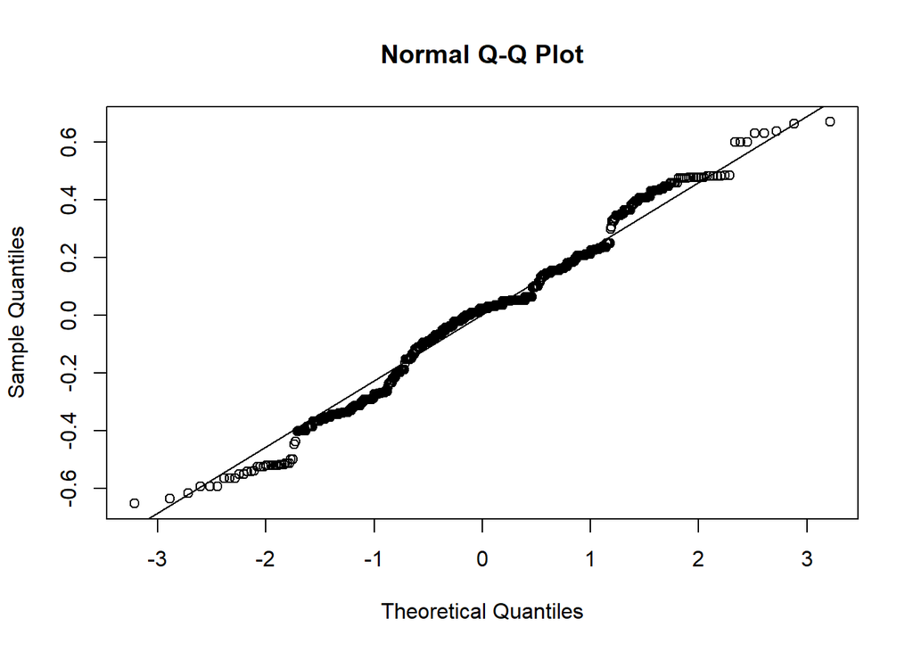

```r
qqnorm(residuals(m)); qqline(residuals(m)) # Q-Q plot
```

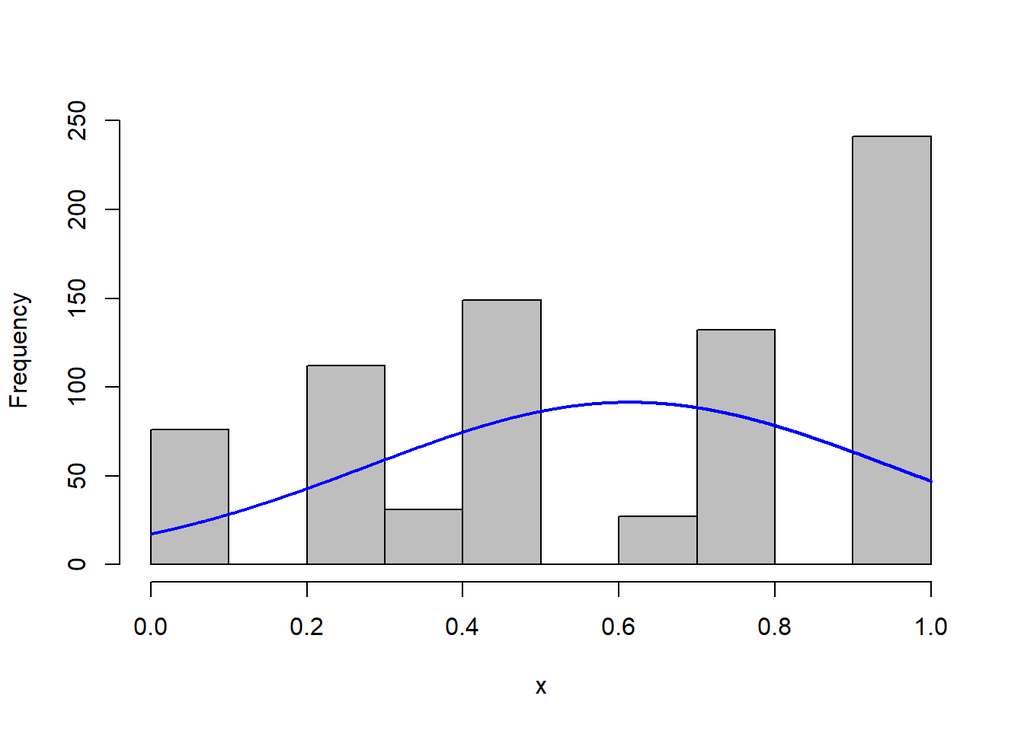

```r
plotNormalHistogram(log_fourlevel_accuracy$accuracy_ave)
```

```r
library(lme4)
library(lmerTest)
library(car)

log_fourlevel_accuracy$id = factor(log_fourlevel_accuracy$id)
contrasts(log_fourlevel_accuracy$targetLevel) <-"contr.sum"
contrasts(log_fourlevel_accuracy$targetKey) <-"contr.sum"
m = glmer(accuracy_ave ~ targetLevel*targetKey + (1|id), data=log_fourlevel_accuracy, family=poisson)
# use family=quasipoissonif overdispersion
Anova(m, type=3)
```

```
## Analysis of Deviance Table (Type III Wald chisquare tests)
##
## Response: accuracy_ave
##                         Chisq Df Pr(>Chisq)
## (Intercept)            0.0503  1     0.8225
## targetLevel           58.3887  3  1.298e-12 ***
## targetKey              0.0524  7     1.0000
## targetLevel:targetKey  2.4638 21     1.0000
## ---
## Signif. codes:  0 '***' 0.001 '**' 0.01 '*' 0.05 '.' 0.1 ' ' 1
```

```r
library(multcomp) # for glht
library(emmeans) # for emm, emmeans
summary(glht(m, emm(pairwise ~ targetLevel)), test=adjusted(type="holm"))
```

```
## NOTE: Results may be misleading due to involvement in interactions
```

```
##
##   Simultaneous Tests for General Linear Hypotheses
##
## Fit: glmer(formula = accuracy_ave ~ targetLevel * targetKey + (1 |
##     id), data = log_fourlevel_accuracy, family = poisson)
##
## Linear Hypotheses:
##                             Estimate Std. Error z value Pr(>|z|)
## full - mediumHigh == 0        1.0111     0.1427   7.085 8.35e-12 ***
## full - mediumLow == 0         0.5800     0.1230   4.717 1.20e-05 ***
## full - light == 0             0.4743     0.1192   3.978 0.000278 ***
## mediumHigh - mediumLow == 0  -0.4311     0.1570  -2.746 0.012051 *
## mediumHigh - light == 0      -0.5369     0.1541  -3.485 0.001478 **
## mediumLow - light == 0       -0.1058     0.1360  -0.778 0.436611
## ---
## Signif. codes:  0 '***' 0.001 '**' 0.01 '*' 0.05 '.' 0.1 ' ' 1
## (Adjusted p values reported -- holm method)
```

```r
# library(ARTool)
# log_fourlevel_accuracy$id = factor(log_fourlevel_accuracy$id) # Subject id must be nominal
# m = art(accuracy_ave ~ targetLevel*targetKey + (1|id), data=log_fourlevel_accuracy) # subjects (S) as random effect
# anova(m)
#
# art.con(m, "targetLevel")
# art.con(m, "targetKey")
# art.con(m, "targetLevel:targetKey")
```

Main effect on targetLevel: Full has highest accuracy; MediumHigh has lowest accuracy

#### time

```r
log_fourLevel_time <- trial_log_filtered%>%
  filter(levelCounts == c("4")) %>%
  group_by(id, targetLevel, targetKey) %>%
  summarize(
    time_ave = sum(time) / n(),
    n_trials = n()
  ) %>%
  ungroup() %>%
  arrange(id, targetLevel, targetKey)
log_fourLevel_time_summary <- log_fourLevel_time  %>%
  group_by(targetLevel, targetKey) %>%
  summarize(
    meanTime = time_ave %>% mean(na.rm=TRUE),
    lowCITime = ci(time_ave)[2] %>% pmax(0),
    highCITime = ci(time_ave)[3],
    sdTime = ci(time_ave)[4],
    stdTime = sd(time_ave)) %>%
  ungroup() %>%
  arrange(targetLevel, targetKey)
log_fourLevel_time_summary
```

```
## # A tibble: 32 × 7
##    targetLevel targetKey meanTime lowCITime highCITime sdTime stdTime
##    <fct>       <fct>        <dbl>     <dbl>      <dbl>  <dbl>   <dbl>
##  1 full        A            1178.     1061.      1295.   56.6    277.
##  2 full        S            1234.     1139.      1328.   45.7    224.
##  3 full        D            1401.     1268.      1534.   64.4    315.
##  4 full        F            1278.     1173.      1383.   50.9    249.
##  5 full        J            1367.     1259.      1474.   51.9    254.
##  6 full        K            1502.     1367.      1637.   65.3    320.
##  7 full        L            1533.     1427.      1639.   51.1    250.
##  8 full        Semicolon    1318.     1162.      1474.   75.4    370.
##  9 mediumHigh  A            1598.     1457.      1739.   68.2    334.
## 10 mediumHigh  S            1642.     1447.      1836.   94.2    461.
## # ℹ 22 more rows
```

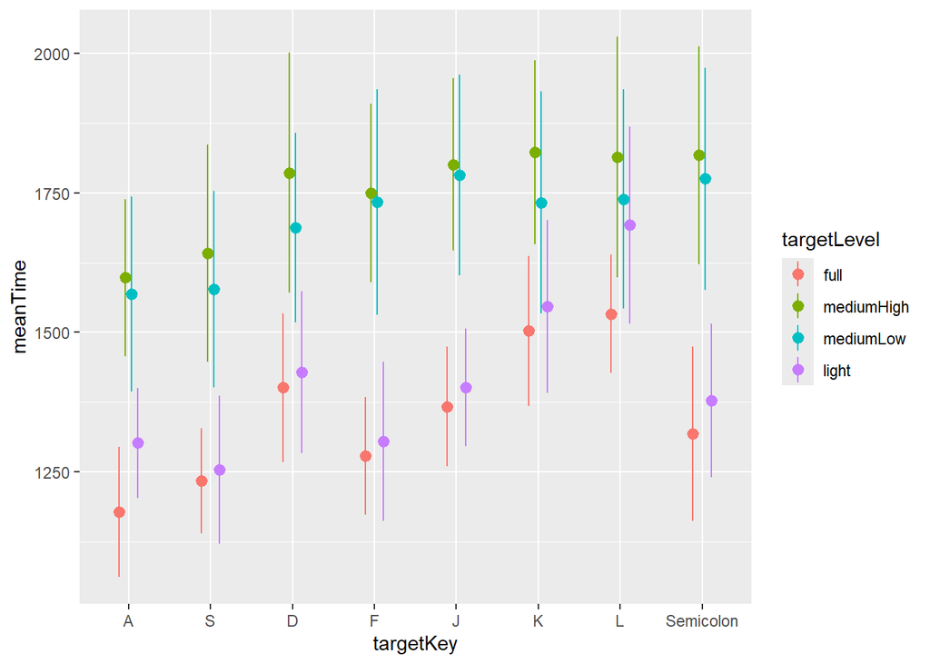

```r
pd <- position_dodge(width = 0.3)
log_fourLevel_time_summary %>% ggplot(
  aes(
    x = targetKey,
    y = meanTime,
    ymin = lowCITime,
    ymax = highCITime,
    color = targetLevel
  )
) +
  geom_pointrange(position = pd)
```

```r
log_fourLevel_time_summary_level <- log_fourLevel_time  %>%
  group_by(targetLevel) %>%
  summarize(
    meanTime = time_ave %>% mean(na.rm=TRUE),
    lowCITime = ci(time_ave)[2] %>% pmax(0),
    highCITime = ci(time_ave)[3],
    sdTime = ci(time_ave)[4],
    stdTime = sd(time_ave)) %>%
  ungroup() %>%
  arrange(targetLevel)

log_fourLevel_time_summary_level
```

```
## # A tibble: 4 × 6
##   targetLevel meanTime lowCITime highCITime sdTime stdTime
##   <fct>          <dbl>     <dbl>      <dbl>  <dbl>   <dbl>
## 1 full           1351.     1308.      1395.   22.0    304.
## 2 mediumHigh     1754.     1693.      1815.   31.1    431.
## 3 mediumLow      1700.     1637.      1763.   32.0    443.
## 4 light          1413.     1363.      1463.   25.3    350.
```

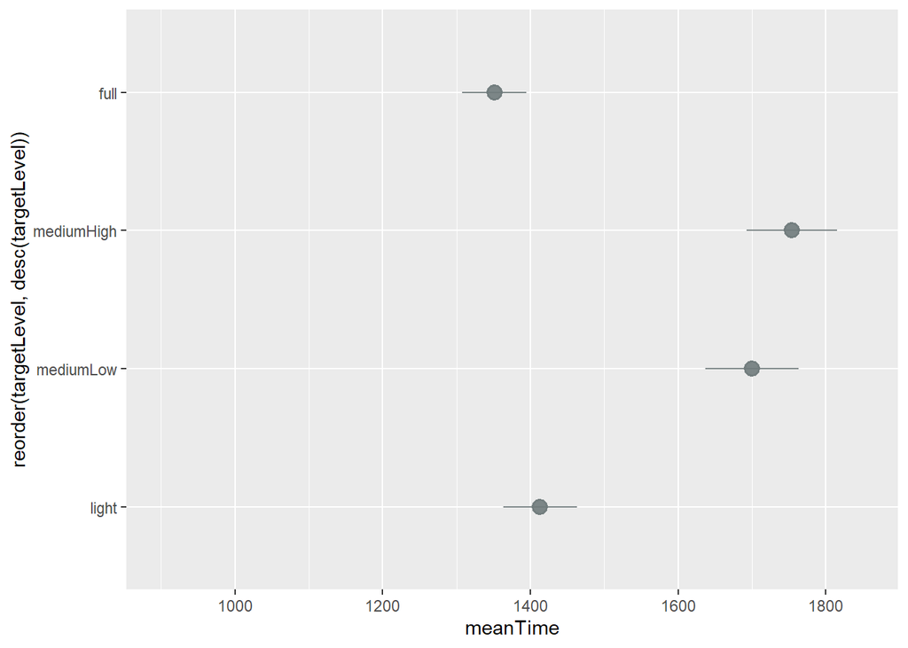

```r
# line + dot (levels)
fourlevel_time_level <- ggplot(log_fourLevel_time_summary_level) +
  geom_pointrange( aes(x=reorder(targetLevel, desc(targetLevel)), y=meanTime, ymin=lowCITime, ymax=highCITime), colour="#707b7c", alpha=0.9, size=0.8) +
  scale_y_continuous(lim=c(900,1850)) +
  coord_flip()

fourlevel_time_level
```

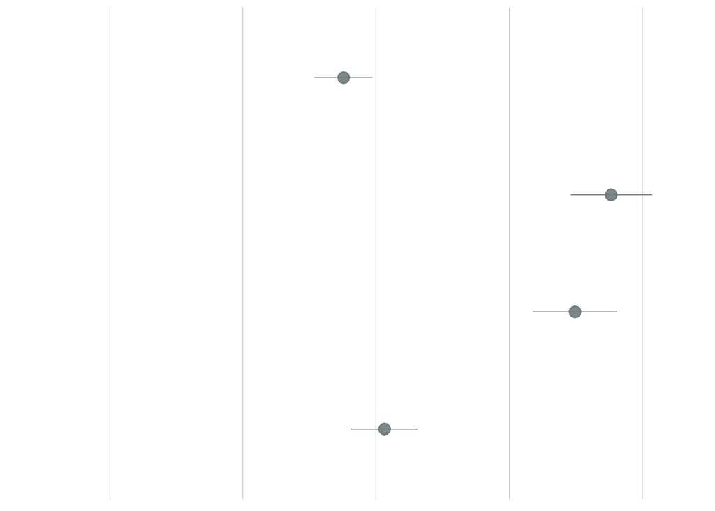

```r
fourlevel_time_level + theme( # remove the vertical grid lines
          panel.background = element_blank(),
          panel.grid.major.y = element_blank() ,
          # explicitly set the horizontal lines (or they will disappear too)
          panel.grid.major.x = element_line( size=.1, color="gray" ),
          axis.title.x = element_blank(),
          axis.text.x=element_blank(),
          axis.ticks.x = element_blank(),
          axis.title.y = element_blank(),
          axis.text.y=element_blank(),
          axis.ticks.y = element_blank()
    )
```

```r
ggsave("4level_time_level.pdf", width = 4, height = 4)


log_fourLevel_time_summary_key <- log_fourLevel_time  %>%
  group_by(targetKey) %>%
  summarize(
    meanTime = time_ave %>% mean(na.rm=TRUE),
    lowCITime = ci(time_ave)[2] %>% pmax(0),
    highCITime = ci(time_ave)[3],
    sdTime = ci(time_ave)[4],
    stdTime = sd(time_ave)) %>%
  ungroup() %>%
  arrange(targetKey)

log_fourLevel_time_summary_key
```

```
## # A tibble: 8 × 6
##   targetKey meanTime lowCITime highCITime sdTime stdTime
##   <fct>        <dbl>     <dbl>      <dbl>  <dbl>   <dbl>
## 1 A            1412.     1338.      1485.   37.1    364.
## 2 S            1427.     1344.      1509.   41.3    405.
## 3 D            1576.     1489.      1662.   43.6    427.
## 4 F            1517.     1429.      1604.   43.9    430.
## 5 J            1588.     1510.      1666.   39.4    386.
## 6 K            1651.     1569.      1734.   41.5    407.
## 7 L            1695.     1608.      1782.   43.8    429.
## 8 Semicolon    1572.     1478.      1666.   47.4    465.
```

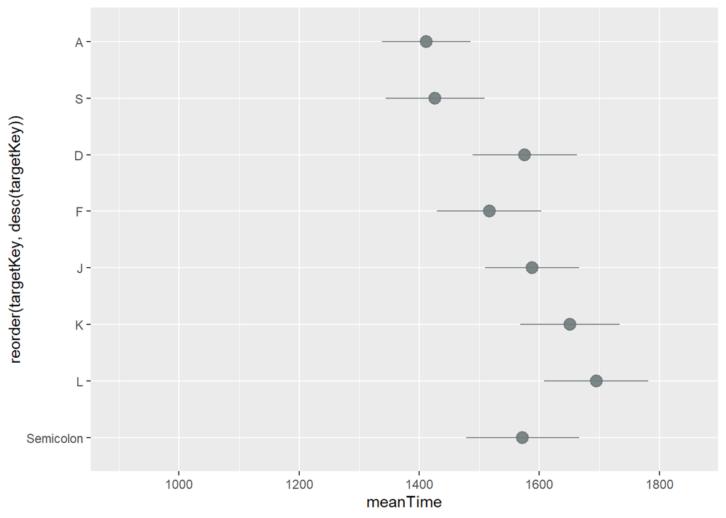

```r
# line + dot (key)
fourlevel_time_key <- ggplot(log_fourLevel_time_summary_key) +
  geom_pointrange( aes(x=reorder(targetKey, desc(targetKey)), y=meanTime, ymin=lowCITime, ymax=highCITime), colour="#707b7c", alpha=0.9, size=0.8) +
  scale_y_continuous(lim=c(900,1850)) +
  coord_flip()

fourlevel_time_key
```

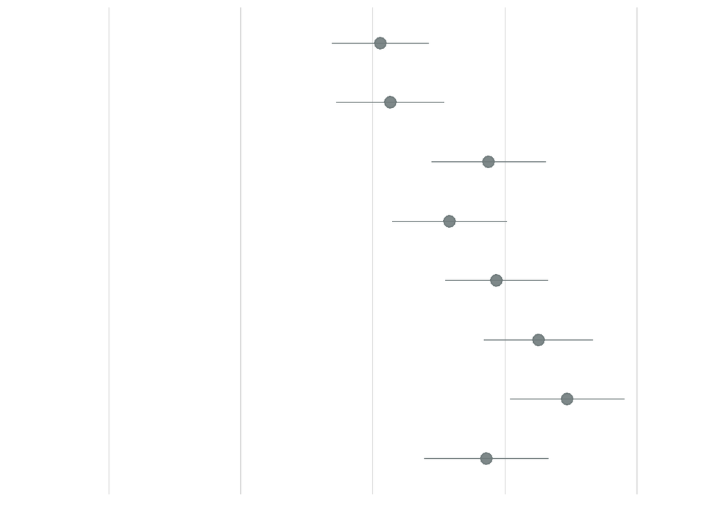

```r
fourlevel_time_key + theme( # remove the vertical grid lines
          panel.background = element_blank(),
          panel.grid.major.y = element_blank() ,
          # explicitly set the horizontal lines (or they will disappear too)
          panel.grid.major.x = element_line( size=.1, color="gray" ),
          axis.title.x = element_blank(),
          axis.text.x=element_blank(),
          axis.ticks.x = element_blank(),
          axis.title.y = element_blank(),
          axis.text.y=element_blank(),
          axis.ticks.y = element_blank()
    )
```

```r
ggsave("4level_time_key.pdf", width = 4, height = 8)
```

#### time analysis

```r
m = aov(time_ave ~ targetLevel*targetKey, data=log_fourLevel_time) # make anova-type linear model
shapiro.test(residuals(m))
```

```
##
##  Shapiro-Wilk normality test
##
## data:  residuals(m)
## W = 0.96876, p-value = 9.532e-12
```

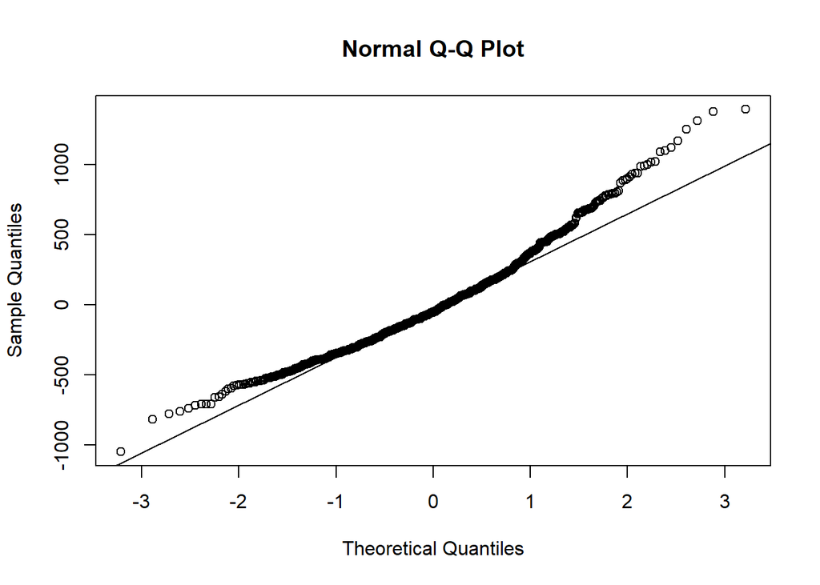

```r
qqnorm(residuals(m)); qqline(residuals(m)) # Q-Q plot
```

```r
library(rcompanion)
log_fourLevel_time$time_ave_trans = transformTukey(log_fourLevel_time$time_ave)
```

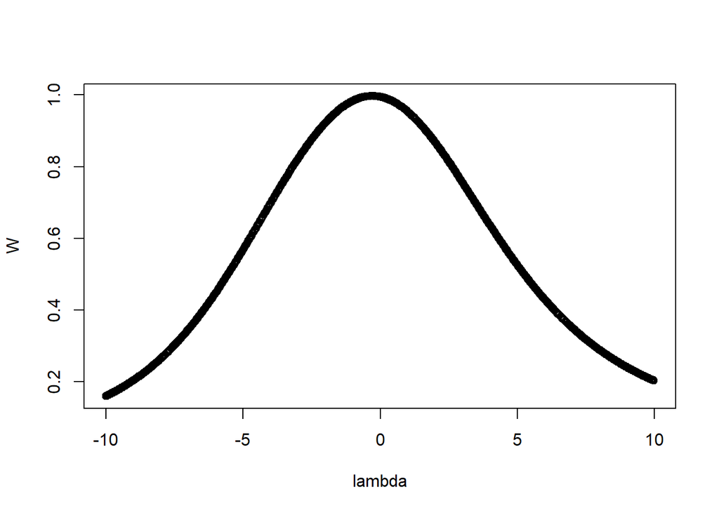

```
##
##     lambda      W Shapiro.p.value
## 388 -0.325 0.9969           0.143
##
## if (lambda >  0){TRANS = x ^ lambda}
## if (lambda == 0){TRANS = log(x)}
## if (lambda <  0){TRANS = -1 * x ^ lambda}
```

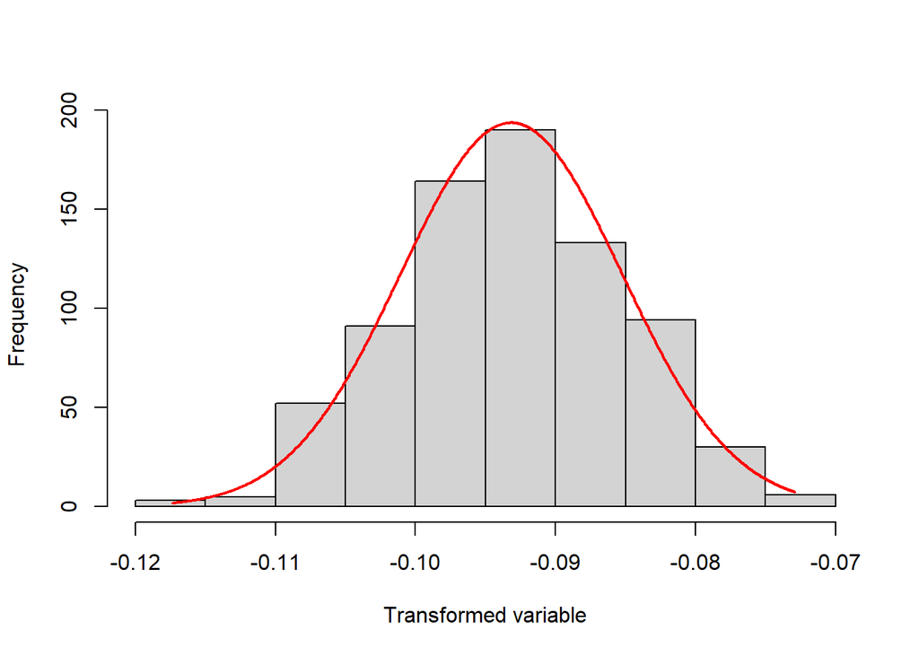

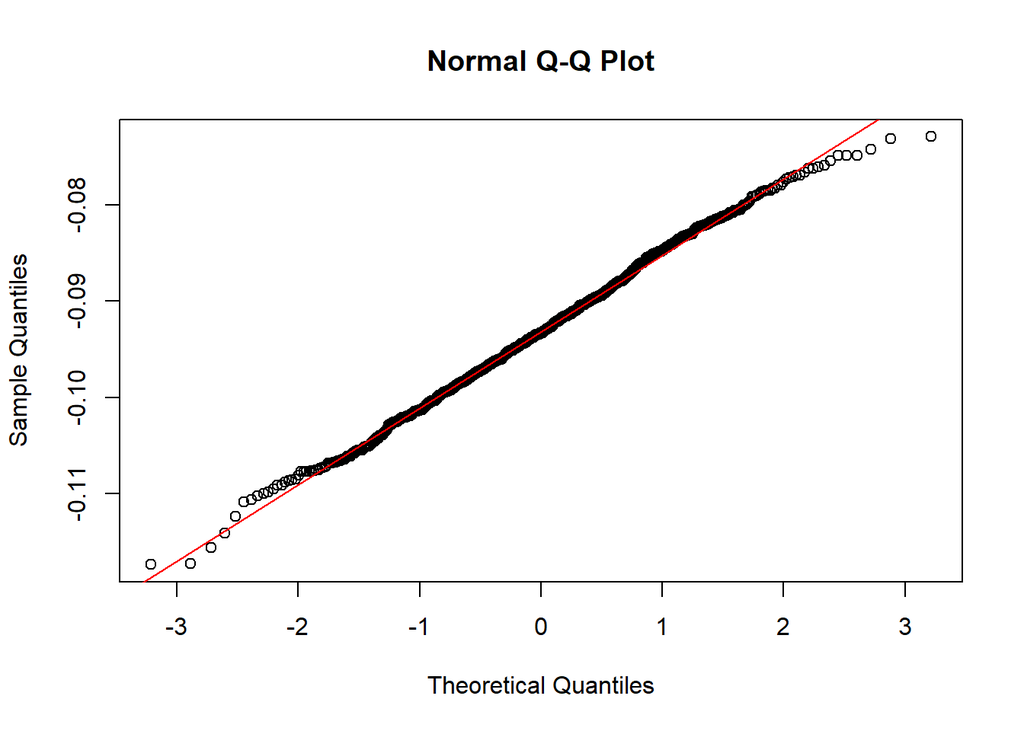

```r
m = aov(time_ave_trans ~ targetLevel*targetKey, data=log_fourLevel_time) # make anova-type linear model
shapiro.test(residuals(m))
```

```
##
##  Shapiro-Wilk normality test
##
## data:  residuals(m)
## W = 0.99777, p-value = 0.403
```

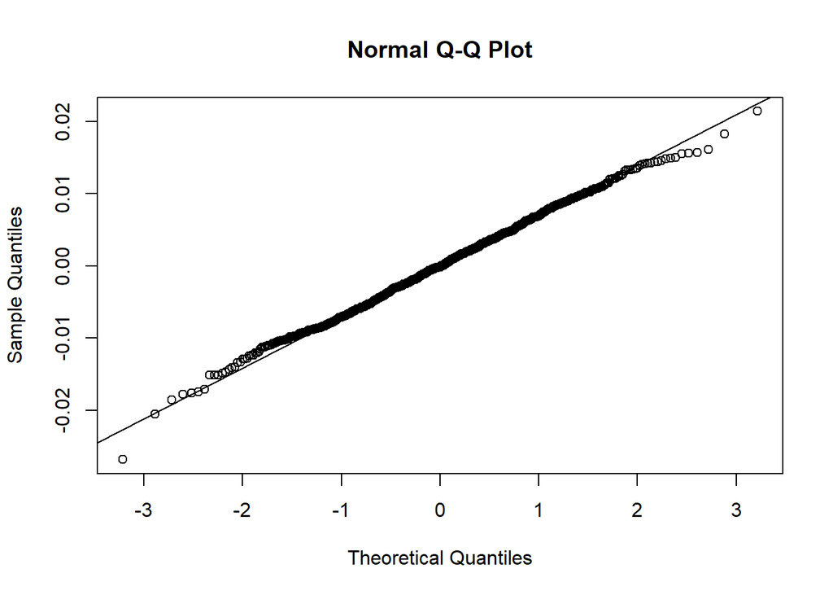

```r
qqnorm(residuals(m)); qqline(residuals(m)) # Q-Q plot
```

```r
library(ez) # for ezANOVA
log_fourLevel_time$id = factor(log_fourLevel_time$id)
m = ezANOVA(dv=time_ave_trans, within=c(targetLevel,targetKey), wid=id, data=log_fourLevel_time)
m$Mauchly # p<.05 indicates a sphericity violation
```

```
##                  Effect            W          p p<.05
## 2           targetLevel 6.415295e-01 0.08651787
## 3             targetKey 1.666743e-01 0.10787720
## 4 targetLevel:targetKey 4.477289e-08 0.16114351
```

```r
m$Sphericity
```

```
##                  Effect       GGe        p[GG] p[GG]<.05       HFe        p[HF]
## 2           targetLevel 0.7918875 1.284837e-17         * 0.8891744 1.673168e-19
## 3             targetKey 0.7270746 2.761154e-14         * 0.9583260 3.933287e-18
## 4 targetLevel:targetKey 0.5182516 1.941587e-03         * 1.0186587 4.202873e-05
##   p[HF]<.05
## 2         *
## 3         *
## 4         *
```

```r
m$ANOVA # use if no violation
```

```
##                  Effect DFn DFd         F            p p<.05        ges
## 2           targetLevel   3  69 74.829044 1.197238e-21     * 0.19159654
## 3             targetKey   7 161 19.584524 7.996444e-19     * 0.07113482
## 4 targetLevel:targetKey  21 483  2.798736 4.202873e-05     * 0.02693423
```

```r
pairwise.t.test(log_fourLevel_time$time_ave_trans, log_fourLevel_time$targetLevel, paired=TRUE, p.adjust="holm")
```

```
##
##  Pairwise comparisons using paired t tests
##
## data:  log_fourLevel_time$time_ave_trans and log_fourLevel_time$targetLevel
##
##            full   mediumHigh mediumLow
## mediumHigh <2e-16 -          -
## mediumLow  <2e-16 0.023      -
## light      0.023  <2e-16     <2e-16
##
## P value adjustment method: holm
```

```r
pairwise.t.test(log_fourLevel_time$time_ave_trans, log_fourLevel_time$targetKey, paired=TRUE, p.adjust="holm")
```

```
##
##  Pairwise comparisons using paired t tests
##
## data:  log_fourLevel_time$time_ave_trans and log_fourLevel_time$targetKey
##
##           A       S       D       F       J       K       L
## S         1.00000 -       -       -       -       -       -
## D         2.1e-06 4.0e-05 -       -       -       -       -
## F         0.01827 0.01967 0.34426 -       -       -       -
## J         3.4e-08 6.0e-07 1.00000 0.01827 -       -       -
## K         1.9e-10 8.1e-09 0.08807 0.00047 0.65568 -       -
## L         8.6e-13 4.6e-12 0.01208 9.6e-05 0.08807 1.00000 -
## Semicolon 6.3e-06 9.4e-05 1.00000 0.55436 1.00000 0.08807 0.00585
##
## P value adjustment method: holm
```

```r
pairwise.t.test(log_fourLevel_time$time_ave_trans, interaction(log_fourLevel_time$targetKey, log_fourLevel_time$targetLevel), paired=TRUE, p.adjust="holm")
```

```
##
##  Pairwise comparisons using paired t tests
##
## data:  log_fourLevel_time$time_ave_trans and interaction(log_fourLevel_time$targetKey, log_fourLevel_time$targetLevel)
##
##                      A.full  S.full  D.full  F.full  J.full  K.full  L.full
## S.full               1.00000 -       -       -       -       -       -
## D.full               0.00123 0.65434 -       -       -       -       -
## F.full               0.26142 1.00000 1.00000 -       -       -       -
## J.full               0.16219 0.64862 1.00000 1.00000 -       -       -
## K.full               0.00046 0.00249 1.00000 0.01475 1.00000 -       -
## L.full               9.7e-05 0.00030 1.00000 0.00195 1.00000 1.00000 -
## Semicolon.full       0.76614 1.00000 1.00000 1.00000 1.00000 1.00000 0.39859
## A.mediumHigh         2.2e-05 1.7e-05 0.44754 0.00096 0.99018 1.00000 1.00000
## S.mediumHigh         1.2e-05 4.6e-05 1.00000 0.00195 1.00000 1.00000 1.00000
## D.mediumHigh         6.6e-07 3.3e-05 0.04684 3.1e-05 0.07316 0.55286 1.00000
## F.mediumHigh         1.6e-09 3.2e-07 0.00172 3.8e-07 0.01092 0.61282 0.25104
## J.mediumHigh         2.0e-08 7.1e-08 0.00017 4.1e-07 0.00039 0.01726 0.51802
## K.mediumHigh         5.7e-07 8.0e-06 0.01407 5.0e-05 0.00951 0.43291 0.90025
## L.mediumHigh         9.7e-06 6.7e-06 0.08152 5.6e-05 0.06013 0.80578 1.00000
## Semicolon.mediumHigh 2.9e-09 1.4e-07 0.00106 1.7e-06 0.01290 0.14890 0.75787
## A.mediumLow          0.00015 0.01156 1.00000 0.05307 1.00000 1.00000 1.00000
## S.mediumLow          6.7e-05 0.00057 1.00000 0.00573 1.00000 1.00000 1.00000
## D.mediumLow          1.8e-07 1.4e-05 0.05025 2.4e-05 0.01574 1.00000 1.00000
## F.mediumLow          1.4e-07 1.3e-06 0.03138 3.5e-06 0.02385 1.00000 1.00000
## J.mediumLow          2.4e-08 2.9e-07 0.01460 3.2e-06 0.01018 0.98859 1.00000
## K.mediumLow          4.8e-06 0.00019 0.08152 0.00035 0.25782 1.00000 1.00000
## L.mediumLow          1.3e-08 7.9e-07 0.02261 9.4e-07 0.02873 0.80410 1.00000
## Semicolon.mediumLow  7.2e-10 2.2e-06 0.00288 6.1e-06 0.03401 1.00000 1.00000
## A.light              0.61282 1.00000 1.00000 1.00000 1.00000 0.84738 0.04164
## S.light              1.00000 1.00000 1.00000 1.00000 1.00000 0.74888 0.20370
## D.light              0.08377 1.00000 1.00000 1.00000 1.00000 1.00000 1.00000
## F.light              1.00000 1.00000 1.00000 1.00000 1.00000 0.16251 0.02139
## J.light              0.00061 0.03681 1.00000 0.36638 1.00000 1.00000 1.00000
## K.light              8.2e-06 0.00127 1.00000 0.00413 1.00000 1.00000 1.00000
## L.light              2.6e-06 7.4e-05 0.03727 0.00087 0.17247 1.00000 1.00000
## Semicolon.light      0.04071 1.00000 1.00000 1.00000 1.00000 1.00000 1.00000
##                      Semicolon.full A.mediumHigh S.mediumHigh D.mediumHigh
## S.full               -              -            -            -
## D.full               -              -            -            -
```

[output cut: 176 more lines]

```
## F.mediumLow          -       -       -
## J.mediumLow          -       -       -
## K.mediumLow          -       -       -
## L.mediumLow          -       -       -
## Semicolon.mediumLow  -       -       -
## A.light              -       -       -
## S.light              -       -       -
## D.light              -       -       -
## F.light              -       -       -
## J.light              -       -       -
## K.light              1.00000 -       -
## L.light              0.13449 1.00000 -
## Semicolon.light      1.00000 1.00000 0.00671
##
## P value adjustment method: holm
```

```r
# library(ARTool)
# log_fourLevel_time$id = factor(log_fourLevel_time$id) # Subject id must be nominal
# m = art(time_ave ~ targetLevel*targetKey + (1|id), data=log_fourLevel_time) # subjects (S) as random effect
# anova(m)
#
# art.con(m, "targetLevel")
# art.con(m, "targetKey")
# art.con(m, "targetLevel:targetKey")
```

Main effect on targetLevel: all pairs have difference

Main effect on targetKey: (AS) faster than (DFJKL;), (DF;) faster than (L), F faster than JK

Main interaction: for Full, ASF is faster than KL, A is faster than D

for Light, AS is faster than KL, F; is faster than L